# Golden Health Index Regression: Full Reproduction

### Server-Based Bootstrap (Production Method)

````markdown
# Large-Scale Bootstrap on Server

## Setup

1. Prepare data file:
   - Ensure `NACC_mod_dat.csv` is in working directory
   - Should contain the full modeling dataset

2. Upload scripts to server:
   - `06_NACC_bootstrap_on_server.R` (main bootstrap code)
   - `07_run_NACC_bootstrap_parallel.sh` (parallel execution script)

3. Create output directory:
   ```bash
   mkdir -p NACC_mod_bs
````

4. Review prediction grid in `06_NACC_bootstrap_on_server.R`:

   ```r
   pred_grid <- list(
     t = 5:25,                    # Age at death - 65 (21 values)
     educ = 16,                   # Education fixed at 16 years
     is_female = c(0, 1),         # Both sexes
     is_married = c(0, 1),        # Married status
     has_comorbidity = c(0, 1),   # Comorbidity
     e4_alleles_1 = c(0, 1),      # One ε4 allele
     e4_alleles_2 = c(0, 1),      # Two ε4 alleles
     is_race_black = c(0, 1),     # Black race
     is_race_other = 0,           # Other race fixed at 0
     l = 1                        # Entry age - 65 fixed at 1
   ) %>% expand.grid()
   ```

## Running

### Option A: Bash Script (Background Jobs)

```bash
cd inst/paper_code
bash 07_run_NACC_bootstrap_parallel.sh
wait  # Wait for all jobs to complete
```

### Option B: Manual Parallel Execution

```bash
# Run 50 files in parallel (FILE_NUM = 1 to 50)
for i in {1..50}; do
  Rscript 06_NACC_bootstrap_on_server.R $i > bs_out_$i.txt 2>&1 &
done
wait
```

## Post-Processing

After bootstrap completes:

1. **Combine files**: All files can be loaded together (as done in bootstrap-check chunk above)
2. **Calculate variance**: Group by grid point and compute empirical variance

   ```r
   bs_variance <- bs_res %>%
     group_by(t, educ, is_female, is_married, has_comorbidity,
              e4_alleles_1, e4_alleles_2, is_race_black, is_race_other, l) %>%
     summarize(
       mean_ghi = mean(ghi_estimate),
       var_ghi = var(ghi_estimate),
       sd_ghi = sd(ghi_estimate),
       .groups = "drop"
     )
   ```

3. **Use in figures**: Bootstrap SE provides confidence bands for GHI plots

[output not shown]

Table 2: Coefficient Estimates for Two-Part Model

|  | Covariate | Estimate | 95% CI | P-value | Estimate | 95% CI | P-value |
| --- | --- | --- | --- | --- | --- | --- | --- |
| t | t (time since age 65) | 0.131 | (0.12, 0.143) | <0.001 | 0.083 | (0.075, 0.09) | <0.001 |
| years_education | Years of education | -0.008 | (-0.029, 0.014) | 0.487 | 0.003 | (-0.016, 0.022) | 0.7580 |
| is_female | Female | -0.099 | (-0.227, 0.029) | 0.130 | -0.119 | (-0.231, -0.008) | 0.0364 |
| is_married | Married | 0.439 | (0.31, 0.567) | <0.001 | -0.028 | (-0.142, 0.087) | 0.6363 |
| comorbidity | ≥1 Comorbidity | 0.015 | (-0.125, 0.155) | 0.830 | 0.463 | (0.344, 0.582) | <0.001 |
| as.factor(num_e4)1 | 1 ε4 allele | 0.527 | (0.386, 0.668) | <0.001 | -0.469 | (-0.596, -0.342) | <0.001 |
| as.factor(num_e4)2 | 2 ε4 alleles | 1.311 | (1.02, 1.601) | <0.001 | -0.422 | (-0.638, -0.206) | <0.001 |
| is_race_black | Black race | -0.719 | (-0.939, -0.498) | <0.001 | -0.266 | (-0.487, -0.045) | 0.0183 |
| is_race_other | Other race | -0.183 | (-0.579, 0.213) | 0.365 | -0.67 | (-1.057, -0.283) | <0.001 |
| l | l (left truncation) | -0.136 | (-0.148, -0.124) | <0.001 | — | — | — |

## Prediction Function

Define the function to compute GHI predictions:

```r
# Update dem_mod_dat with full model data
mod_dat <- mod_dat %>%
  mutate(
    num_e4_1 = ifelse(num_e4 == 1, 1, 0),
    num_e4_2 = ifelse(num_e4 == 2, 1, 0)
  )
dem_mod_dat <- mod_dat %>% filter(got_dementia == 1)

predict_ghi <- function(mod1, mod2, t, educ, is_female, is_married,
                       has_comorbidity, e4_alleles_1, e4_alleles_2,
                       is_race_black, is_race_other, l) {

  # Part 1: Probability of dementia
  lp_mu <- sum(mod1$coefficients[-1] *
                 c(t, educ, is_female, is_married, has_comorbidity,
                   e4_alleles_1, e4_alleles_2, is_race_black, is_race_other, l))
  mu <- exp(lp_mu) / (1 + exp(lp_mu))

  var_mu <- (mu * (1 - mu))^2 *
    c(1, t, educ, is_female, is_married, has_comorbidity,
      e4_alleles_1, e4_alleles_2, is_race_black, is_race_other, l) %*%
    vcov(mod1) %*%
    c(1, t, educ, is_female, is_married, has_comorbidity,
      e4_alleles_1, e4_alleles_2, is_race_black, is_race_other, l)

  # Part 2: Expected timing given dementia
  lp_y <- sum(mod2$parameters$beta *
                c(t, educ, is_female, is_married, has_comorbidity,
                  e4_alleles_1, e4_alleles_2, is_race_black, is_race_other))

  sd_lp_y <- c(t, educ, is_female, is_married, has_comorbidity,
               e4_alleles_1, e4_alleles_2, is_race_black, is_race_other) %*%
    vcov(mod2) %*%
    c(t, educ, is_female, is_married, has_comorbidity,
      e4_alleles_1, e4_alleles_2, is_race_black, is_race_other)

  # Kaplan-Meier integration for E[Y | dementia]
  mod_l <- log((l/t) / (1 - (l/t)))
  lower_bound <- mod_l - lp_y

  tau <- dem_mod_dat %>%
    mutate(l_resid_scale = mod_l - lp_y) %>%
    pull(l_resid_scale)

  km_df <- data.frame(
    epsilon = mod2$data$residuals,
    tau = tau,
    delta = 1
  ) %>%
    mutate(
      g_of_e = exp(lp_y + epsilon) / (1 + exp(lp_y + epsilon)),
      g_of_t = exp(lp_y + tau) / (1 + exp(lp_y + tau))
    ) %>%
    filter(epsilon > lower_bound, g_of_e > g_of_t)

  if (nrow(km_df) < 3) return(data.frame())

  km_fit <- tryCatch({
    survfit(Surv(time = g_of_t, time2 = g_of_e, event = delta) ~ 1, data = km_df)
  }, error = function(e) return(NULL))

  if (is.null(km_fit)) return(data.frame())

  km_times <- c(0, km_fit$time)
  km_surv <- c(1, km_fit$surv)
  km_estimate <- sum(km_surv[-length(km_surv)] * diff(km_times))

  # GHI = E[min(T, S)] = (1-mu) + mu * E[Y | dementia]
  ghi_estimate <- (1 - mu) + mu * km_estimate

  data.frame(
    t = t, educ = educ, is_female = is_female, is_married = is_married,
    has_comorbidity = has_comorbidity, e4_alleles_1 = e4_alleles_1,
    e4_alleles_2 = e4_alleles_2, is_race_black = is_race_black,
    is_race_other = is_race_other, l = l,
    lp_mu = lp_mu, mu = mu, var_mu = var_mu,
    lp_y = lp_y, sd_lp_y = sd_lp_y,
    expected_y = km_estimate,
    ghi_estimate = ghi_estimate
  )
}
```

## Generate Predictions

```r
cat("Generating predictions across covariate grid...\n")
```

```
## Generating predictions across covariate grid...
```

```r
pred_grid <- expand.grid(
  t = c(0.5, 1:25),
  educ = 16,
  is_female = c(0, 1),
  is_married = c(0, 1),
  has_comorbidity = c(0, 1),
  e4_alleles_1 = c(0, 1),
  e4_alleles_2 = c(0, 1),
  is_race_black = c(0, 1),
  is_race_other = c(0,1),
  l = 1
)

# Remove invalid combinations (can't have both e4 alleles)
pred_grid <- pred_grid %>%
  filter(!(e4_alleles_1 == 1 & e4_alleles_2 == 1))

cat("Prediction grid size:", nrow(pred_grid), "combinations\n")
```

```
## Prediction grid size: 2496 combinations
```

```r
cat("Computing predictions (this may take 1-2 minutes)...\n\n")
```

```
## Computing predictions (this may take 1-2 minutes)...
```

```r
tic()
res <- pred_grid %>%
  pmap_dfr(function(...) {
    args <- list(...)
    predict_ghi(
      part_1_mod, part_2_mod_clean,
      t = args$t, educ = args$educ, is_female = args$is_female,
      is_married = args$is_married, has_comorbidity = args$has_comorbidity,
      e4_alleles_1 = args$e4_alleles_1, e4_alleles_2 = args$e4_alleles_2,
      is_race_black = args$is_race_black, is_race_other = args$is_race_other,
      l = args$l
    )
  })
toc()
```

```
## 9.213 sec elapsed
```

```r
cat("\n✓ Generated", nrow(res), "predictions\n")
```

```
##
## ✓ Generated 2304 predictions
```

## Figures 1 and 2: GHI by Age, Race, Sex, Marital Status, Comorbidity, and APOE Status

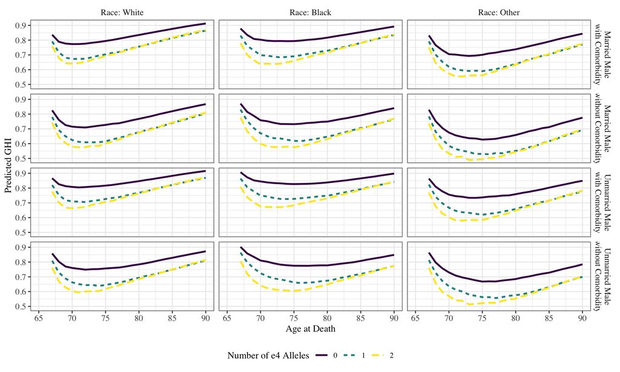

```r
fig1 <- res %>%
  mutate(
    Race = case_when(
      is_race_black == 1 ~ "Race: Black",
      is_race_other == 1 ~ "Race: Other",
      TRUE ~ "Race: White"
    ),
    Race = factor(Race, levels = c("Race: White", "Race: Black", "Race: Other")),
    married_str = ifelse(is_married == 1, "Married", "Unmarried"),
    sex_str = ifelse(is_female == 1, "Female", "Male"),
    comorbidity_str = ifelse(has_comorbidity == 1, "with Comorbidity", "without Comorbidity"),
    Group = paste0(married_str, " ", sex_str, "\n", comorbidity_str)
  ) %>%
  filter(is_female == 0) %>%
  filter(educ == 16) %>%
  filter(!(e4_alleles_2 == 1 & e4_alleles_1 == 1)) %>%
  filter(!(is_race_black == 1 & is_race_other == 1)) %>%
  mutate(
    num_e4 = case_when(
      e4_alleles_2 == 1 ~ 2,
      e4_alleles_1 == 1 ~ 1,
      TRUE ~ 0
    ),
    Comorbidity = ifelse(has_comorbidity == 1, "Yes", "No"),
    Sex = ifelse(is_female == 1, "Female", "Male")#,
    # lower = ghi_estimate - 2 * sd_ghi,
    # upper = ghi_estimate + 2 * sd_ghi
  ) %>%
  ggplot() +
  aes(x = t + 65, y = ghi_estimate, color = as.factor(num_e4), fill = as.factor(num_e4)) +
  # {if(all(!is.na(res_w_var$sd_ghi))) geom_ribbon(aes(ymin = lower, ymax = upper), alpha = 0.3, color = NA)} +
  geom_line(aes(lty = as.factor(num_e4)), size = 1) +
  facet_grid(Group ~ Race, labeller = "label_value") +
  theme_bw() +
  theme(
    legend.position = "bottom",
    text = element_text(family = "Times"),
    strip.background = element_blank(),
    strip.text = element_text(size = 10),
    axis.text = element_text(size = 10),
    plot.title = element_text(hjust = 0.5)
  ) +
  labs(x = "Age at Death", y = "Predicted GHI", color = "Number of e4 Alleles", fill = "Number of e4 Alleles", lty = "Number of e4 Alleles") +
  scale_color_viridis_d() +
  scale_fill_viridis_d() +
  xlim(c(65, 90))

print(fig1)
```

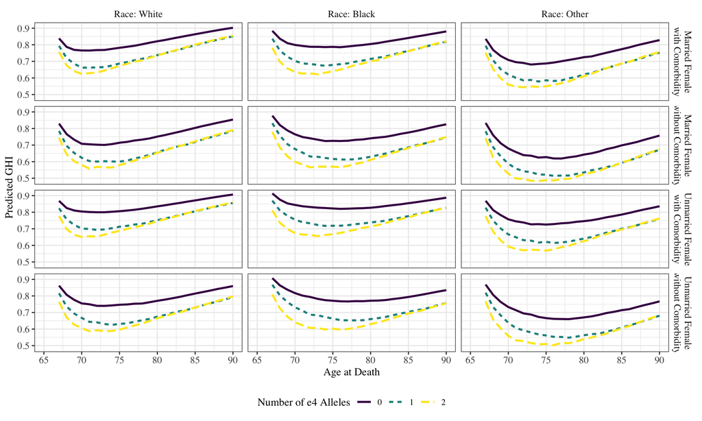

```r
      # Save figure
ggsave(fs::path(RESULTS_DIR, "figure1.png"),
       fig1, width = 12, height = 7, dpi = 300)

fig2 <- res %>%
  mutate(
    Race = case_when(
      is_race_black == 1 ~ "Race: Black",
      is_race_other == 1 ~ "Race: Other",
      TRUE ~ "Race: White"
    ),
    Race = factor(Race, levels = c("Race: White", "Race: Black", "Race: Other")),
    married_str = ifelse(is_married == 1, "Married", "Unmarried"),
    sex_str = ifelse(is_female == 1, "Female", "Male"),
    comorbidity_str = ifelse(has_comorbidity == 1, "with Comorbidity", "without Comorbidity"),
    Group = paste0(married_str, " ", sex_str, "\n", comorbidity_str)
  ) %>%
  filter(is_female == 1) %>%
  filter(educ == 16) %>%
  filter(!(e4_alleles_2 == 1 & e4_alleles_1 == 1)) %>%
  filter(!(is_race_black == 1 & is_race_other == 1)) %>%
  mutate(
    num_e4 = case_when(
      e4_alleles_2 == 1 ~ 2,
      e4_alleles_1 == 1 ~ 1,
      TRUE ~ 0
    ),
    Comorbidity = ifelse(has_comorbidity == 1, "Yes", "No"),
    Sex = ifelse(is_female == 1, "Female", "Male")#,
    # lower = ghi_estimate - 2 * sd_ghi,
    # upper = ghi_estimate + 2 * sd_ghi
  ) %>%
  ggplot() +
  aes(x = t + 65, y = ghi_estimate, color = as.factor(num_e4), fill = as.factor(num_e4)) +
  # {if(all(!is.na(res_w_var$sd_ghi))) geom_ribbon(aes(ymin = lower, ymax = upper), alpha = 0.3, color = NA)} +
  geom_line(aes(lty = as.factor(num_e4)), size = 1) +
  facet_grid(Group ~ Race, labeller = "label_value") +
  theme_bw() +
  theme(
    legend.position = "bottom",
    text = element_text(family = "Times"),
    strip.background = element_blank(),
    strip.text = element_text(size = 10),
    axis.text = element_text(size = 10),
    plot.title = element_text(hjust = 0.5)
  ) +
  labs(x = "Age at Death", y = "Predicted GHI", color = "Number of e4 Alleles", fill = "Number of e4 Alleles", lty = "Number of e4 Alleles") +
  scale_color_viridis_d() +
  scale_fill_viridis_d() +
  xlim(c(65, 90))

print(fig2)
```

```r
      # Save figure
ggsave(fs::path(RESULTS_DIR, "figure2.png"),
       fig2, width = 12, height = 7, dpi = 300)
```

# 5. Model Checking

Comprehensive diagnostics for both parts of the model.

## Part 1 Diagnostics

### Surrogate Residuals

```r
cat("Computing surrogate residuals for Part 1 model...\n")
```

```
## Computing surrogate residuals for Part 1 model...
```

```r
# Refit Part 1 with y = TRUE to access response
part_1_mod_check <- glm(
  got_dementia ~ t + years_education + is_female + is_married + comorbidity +
    as.factor(num_e4) + is_race_black + is_race_other + l,
  data = mod_dat,
  family = "binomial",
  y = TRUE
)

# Surrogate residuals function
surrogate_residuals_logistic <- function(model, nsim = 1, seed = NULL) {
  if (!is.null(seed)) set.seed(seed)

  y <- model$y
  if (is.null(y)) stop("Model must be fit with y = TRUE")

  p <- fitted(model)
  n <- length(y)
  res <- matrix(NA_real_, nrow = n, ncol = nsim)

  for (s in seq_len(nsim)) {
    U <- numeric(n)
    for (i in seq_len(n)) {
      if (y[i] == 0) {
        U[i] <- runif(1, min = 0, max = 1 - p[i])
      } else {
        U[i] <- runif(1, min = 1 - p[i], max = 1)
      }
    }
    res[, s] <- qnorm(U)
  }

  if (nsim == 1) drop(res) else res
}

set.seed(26339)
r <- surrogate_residuals_logistic(part_1_mod_check, seed = 26339)
R <- surrogate_residuals_logistic(part_1_mod_check, nsim = 100, seed = 26339)

cat("✓ Computed surrogate residuals\n")
```

```
## ✓ Computed surrogate residuals
```

### QQ Plot

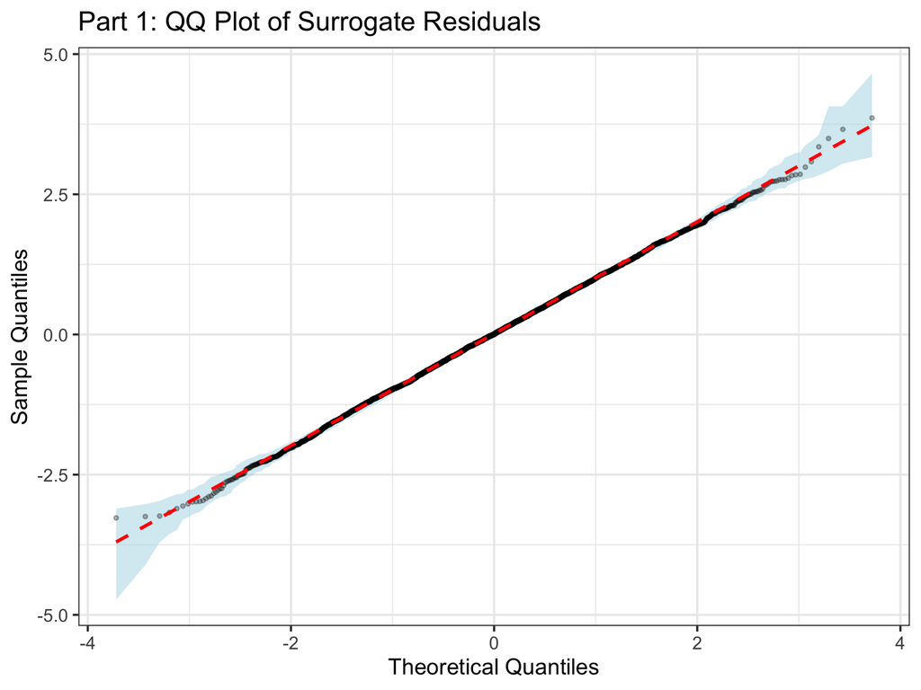

```r
# QQ plot envelope
qq_data <- apply(R, 2, sort)
env_bottom <- apply(qq_data, 1, min)
env_top <- apply(qq_data, 1, max)

qq_plot <- ggplot() +
  aes(sample = r) +
  geom_ribbon(
    aes(x = qnorm(ppoints(nrow(R))), ymin = env_bottom, ymax = env_top),
    fill = "lightblue",
    alpha = 0.5
  ) +
  geom_qq(alpha = 0.3, size = 1) +
  geom_qq_line(color = "red", lty = "dashed", size = 1) +
  labs(
    title = "Part 1: QQ Plot of Surrogate Residuals",
    x = "Theoretical Quantiles",
    y = "Sample Quantiles"
  ) +
  theme_bw(base_size = 14)

print(qq_plot)
```

### Hosmer-Lemeshow Test

```r
# Hosmer-Lemeshow goodness of fit test
hl_test <- hoslem.test(part_1_mod_check$y, fitted(part_1_mod_check), g = 10)

cat("Hosmer-Lemeshow Test:\n")
```

```
## Hosmer-Lemeshow Test:
```

```r
cat("  Chi-squared:", round(hl_test$statistic, 3), "\n")
```

```
##   Chi-squared: 30.225
```

```r
cat("  df:", hl_test$parameter, "\n")
```

```
##   df: 8
```

```r
cat("  p-value:", format.pval(hl_test$p.value, digits = 3), "\n\n")
```

```
##   p-value: 0.000193
```

```r
if (hl_test$p.value > 0.05) {
  cat("✓ Good fit (fail to reject null hypothesis of good calibration)\n")
} else {
  cat("⚠ Potential calibration issues (reject null hypothesis)\n")
}
```

```
## ⚠ Potential calibration issues (reject null hypothesis)
```

### Calibration Plot

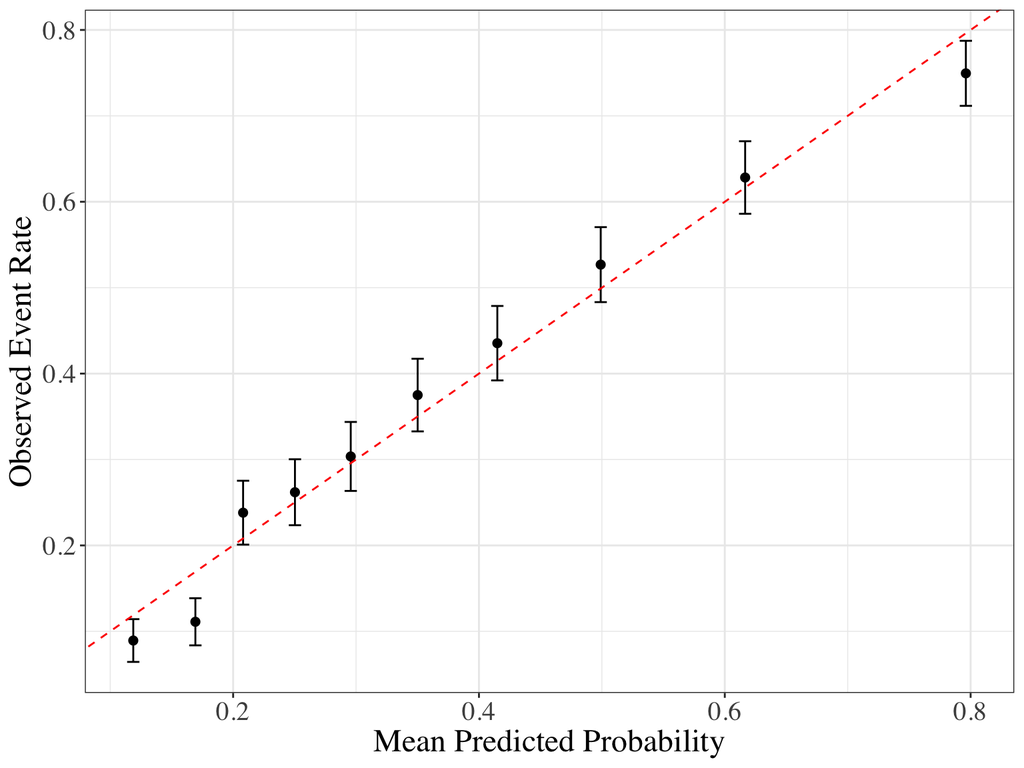

```r
hl <- hoslem.test(
  x = mod_dat$got_dementia,
  y = fitted(part_1_mod),
  g = 10
)

hl_data <- data.frame(
  observed = hl$observed[, 2],
  expected = hl$expected[, 2],
  group = seq_len(nrow(hl$observed))
)

calib <- mod_dat %>%
  mutate(
    p_hat = fitted(part_1_mod),
    group = ntile(p_hat, 10)
  ) %>%
  group_by(group) %>%
  summarize(
    mean_p = mean(p_hat),
    obs_rate = mean(got_dementia),
    n = n(),
    .groups = "drop"
  ) %>%
  mutate(
    se = sqrt(obs_rate * (1 - obs_rate) / n),
    lower = obs_rate - 1.96 * se,
    upper = obs_rate + 1.96 * se
  )

cal_plot <- calib %>%
  ggplot() +
  geom_point(
    aes(x = mean_p, y = obs_rate),
    size = 2
  ) +
  geom_segment(
    aes(x = mean_p, xend = mean_p, y = lower, yend = upper)
  ) +
  geom_segment(
    aes(x = mean_p - 0.005, xend = mean_p + 0.005, y = lower, yend = lower)
  ) +
  geom_segment(
    aes(x = mean_p - 0.005, xend = mean_p + 0.005, y = upper, yend = upper)
  ) +
  geom_abline(slope = 1, intercept = 0, color = "red", lty = "dashed") +
  xlab("Mean Predicted Probability") +
  ylab("Observed Event Rate") +
  theme_bw() +
  theme(
    legend.position = "bottom",
    text = element_text(family = "Times"),
    strip.background = element_blank(),
    strip.text = element_text(size = 15),
    axis.text = element_text(size = 15),
    axis.title = element_text(size = 18)
  )

print(cal_plot)
```

### VIF (Multicollinearity)

```r
# Variance Inflation Factors
vif_values <- car::vif(part_1_mod_check)

cat("Variance Inflation Factors (VIF):\n")
```

```
## Variance Inflation Factors (VIF):
```

```r
print(round(vif_values, 2))
```

```
##                   GVIF Df GVIF^(1/(2*Df))
## t                 1.91  1            1.38
## years_education   1.00  1            1.00
## is_female         1.02  1            1.01
## is_married        1.00  1            1.00
## comorbidity       1.00  1            1.00
## as.factor(num_e4) 1.06  2            1.01
## is_race_black     1.03  1            1.02
## is_race_other     1.04  1            1.02
## l                 1.92  1            1.38
```

```r
max_vif <- max(vif_values)
cat("\nMax VIF:", round(max_vif, 2), "\n")
```

```
##
## Max VIF: 2
```

```r
if (max_vif < 5) {
  cat("✓ No multicollinearity concerns (all VIF < 5)\n")
} else if (max_vif < 10) {
  cat("⚠ Moderate multicollinearity (some VIF between 5-10)\n")
} else {
  cat("⚠ Severe multicollinearity (some VIF > 10)\n")
}
```

```
## ✓ No multicollinearity concerns (all VIF < 5)
```

### Cook’s Distance

```r
# Cook's distance
cooks_d <- cooks.distance(part_1_mod_check)

# Cutoff: 4 / n
cutoff <- 4 / nrow(mod_dat)
influential <- which(cooks_d > cutoff)

cat("Cook's Distance Analysis:\n")
```

```
## Cook's Distance Analysis:
```

```r
cat("  Cutoff (4/n):", round(cutoff, 6), "\n")
```

```
##   Cutoff (4/n): 0.000794
```

```r
cat("  Influential points:", length(influential), "of", nrow(mod_dat), "\n")
```

```
##   Influential points: 187 of 5036
```

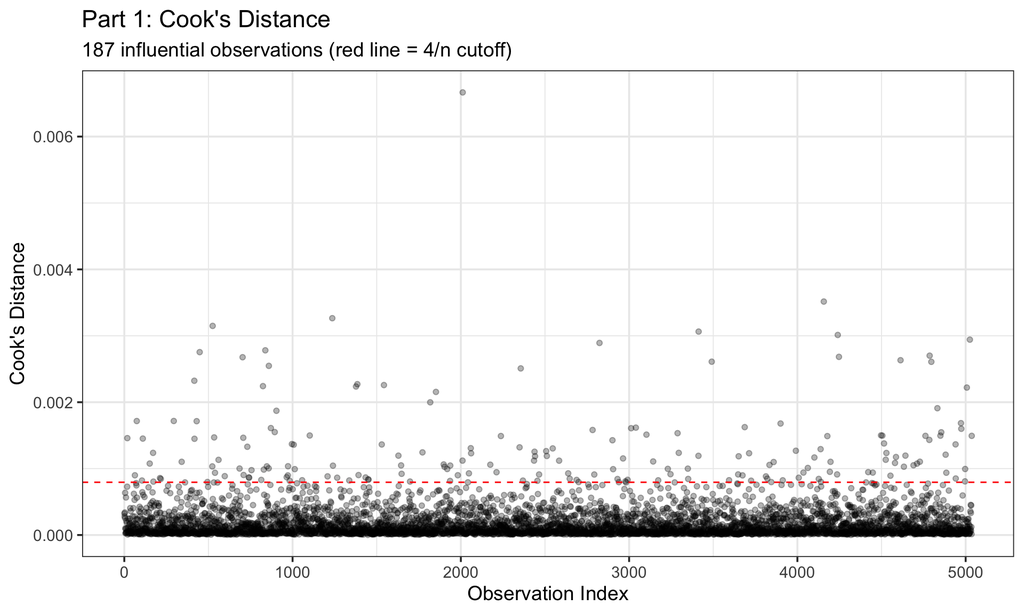

```r
# Plot
cooks_plot <- ggplot(data.frame(index = 1:length(cooks_d), cooks = cooks_d),
                     aes(x = index, y = cooks)) +
  geom_point(alpha = 0.3) +
  geom_hline(yintercept = cutoff, color = "red", lty = "dashed") +
  labs(
    title = "Part 1: Cook's Distance",
    subtitle = paste0(length(influential), " influential observations (red line = 4/n cutoff)"),
    x = "Observation Index",
    y = "Cook's Distance"
  ) +
  theme_bw(base_size = 14)

print(cooks_plot)
```

```r
# Refit without influential points
if (length(influential) > 0 && length(influential) < nrow(mod_dat) * 0.1) {
  cat("\nRefitting model without influential points...\n")
  mod_dat_no_influential <- mod_dat[-influential, ]

  part_1_mod_robust <- glm(
    got_dementia ~ t + years_education + is_female + is_married + comorbidity +
      as.factor(num_e4) + is_race_black + is_race_other + l,
    data = mod_dat_no_influential,
    family = "binomial"
  )

  # Compare coefficients
  coef_comparison <- data.frame(
    Original = coef(part_1_mod_check),
    Robust = coef(part_1_mod_robust),
    Difference = coef(part_1_mod_robust) - coef(part_1_mod_check),
    Pct_Change = (coef(part_1_mod_robust) - coef(part_1_mod_check)) / coef(part_1_mod_check) * 100
  )

  cat("\nCoefficient comparison (original vs. robust):\n")
  print(round(coef_comparison, 4))

  max_pct_change <- max(abs(coef_comparison$Pct_Change), na.rm = TRUE)
  if (max_pct_change < 10) {
    cat("\n✓ Robust model similar (max change < 10%)\n")
  } else {
    cat("\n⚠ Substantial changes detected (max change > 10%)\n")
  }
}
```

```
##
## Refitting model without influential points...
##
## Coefficient comparison (original vs. robust):
##                    Original  Robust Difference Pct_Change
## (Intercept)         -1.9537 -2.3053    -0.3517    17.9995
## t                    0.1314  0.1612     0.0299    22.7225
## years_education     -0.0075 -0.0080    -0.0005     6.0988
## is_female           -0.0988 -0.1120    -0.0133    13.4225
## is_married           0.4385  0.5740     0.1354    30.8849
## comorbidity          0.0154 -0.0224    -0.0378  -245.7188
## as.factor(num_e4)1   0.5269  0.6072     0.0803    15.2414
## as.factor(num_e4)2   1.3105  1.9243     0.6138    46.8348
## is_race_black       -0.7187 -1.5346    -0.8160   113.5415
## is_race_other       -0.1831 -0.9646    -0.7815   426.6868
## l                   -0.1357 -0.1663    -0.0306    22.5276
##
## ⚠ Substantial changes detected (max change > 10%)
```

Note that while there are some substantial changes, they occur in groups that had a small number of individuals to begin with. Further, the key here is to assess if outliers are impacting our main conclusions for the APOE covariates, which they are not since the robust estimates are in the same direction, and actually have a larger magnitude when fit.

### Linearity Check

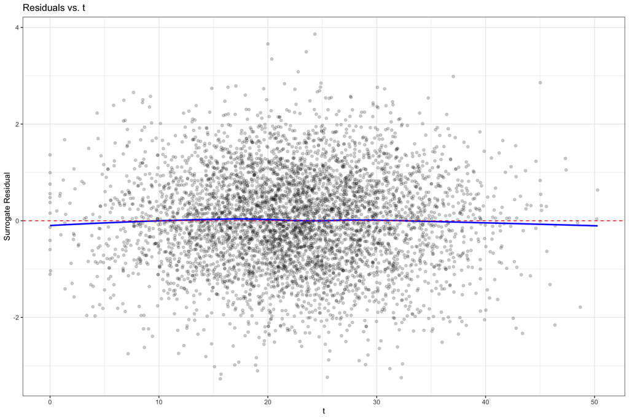

```r
# Check linearity assumption for continuous predictors
eta <- predict(part_1_mod_check, type = "link")

linearity_plots <- list()

# t
p1 <- ggplot(data.frame(t = mod_dat$t, r = r), aes(x = t, y = r)) +
  geom_point(alpha = 0.2) +
  geom_smooth(method = "loess", color = "blue", se = FALSE) +
  geom_hline(yintercept = 0, color = "red", lty = "dashed") +
  labs(title = "Residuals vs. t", x = "t", y = "Surrogate Residual") +
  theme_bw()

# Education
p2 <- ggplot(data.frame(educ = mod_dat$years_education, r = r),
             aes(x = educ, y = r)) +
  geom_point(alpha = 0.2) +
  geom_smooth(method = "loess", color = "blue", se = FALSE) +
  geom_hline(yintercept = 0, color = "red", lty = "dashed") +
  labs(title = "Residuals vs. Education", x = "Years of Education",
       y = "Surrogate Residual") +
  theme_bw()

# l
p3 <- ggplot(data.frame(l = mod_dat$l, r = r), aes(x = l, y = r)) +
  geom_point(alpha = 0.2) +
  geom_smooth(method = "loess", color = "blue", se = FALSE) +
  geom_hline(yintercept = 0, color = "red", lty = "dashed") +
  labs(title = "Residuals vs. l", x = "l", y = "Surrogate Residual") +
  theme_bw()

# Linear predictor
p4 <- ggplot(data.frame(eta = eta, r = r), aes(x = eta, y = r)) +
  geom_point(alpha = 0.2) +
  geom_smooth(method = "loess", color = "blue", se = FALSE) +
  geom_hline(yintercept = 0, color = "red", lty = "dashed") +
  labs(title = "Residuals vs. Linear Predictor", x = "Linear Predictor",
       y = "Surrogate Residual") +
  theme_bw()

# Combine plots
print(p1)
```

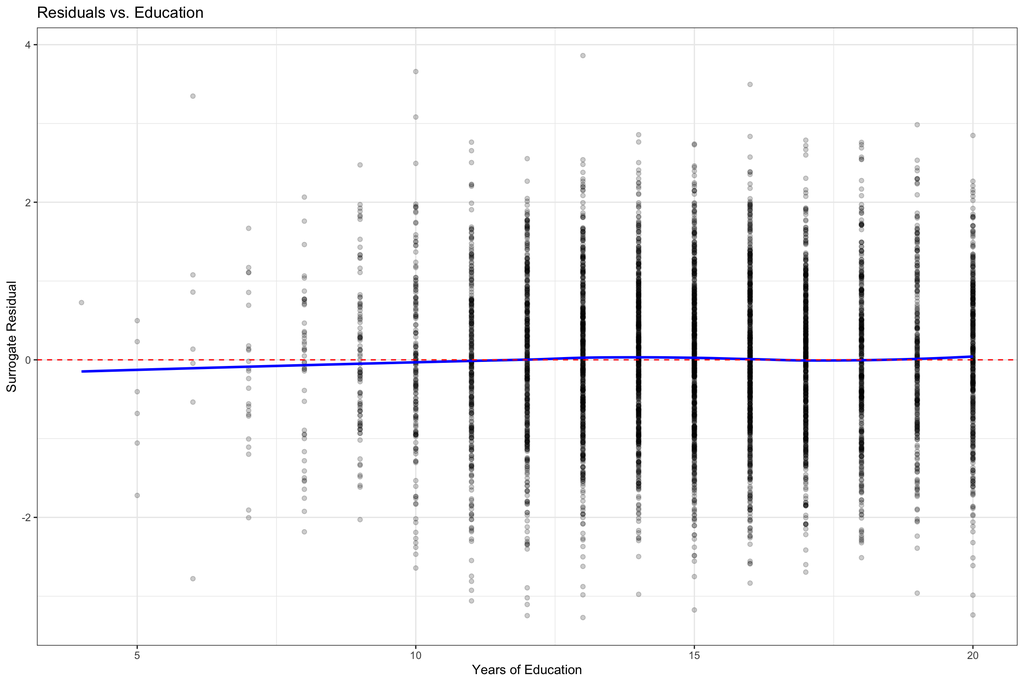

```r
print(p2)
```

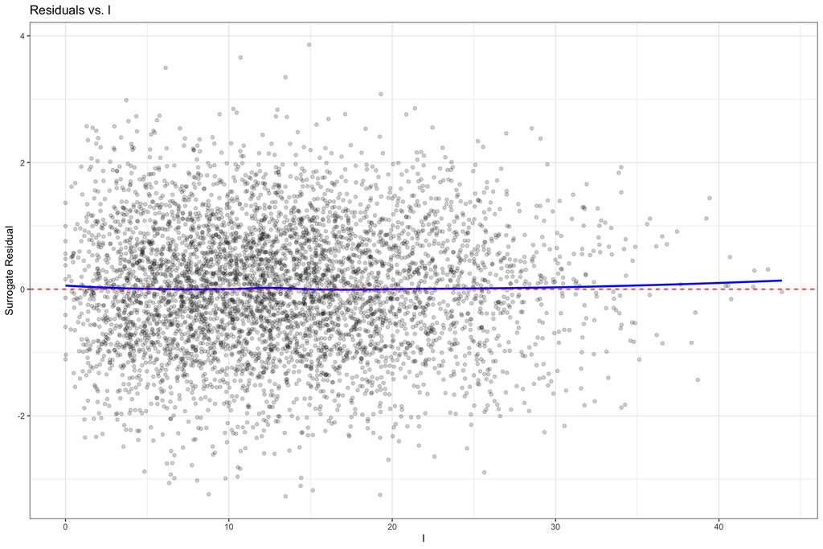

```r
print(p3)
```

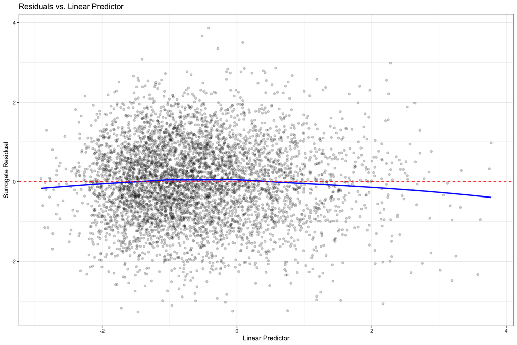

```r
print(p4)
```

### Likelihood Ratio Test (Splines)

```r
cat("Testing spline alternatives for continuous predictors...\n\n")
```

```
## Testing spline alternatives for continuous predictors...
```

```r
# Test splines for t
part_1_mod_t_spline <- glm(
  got_dementia ~ ns(t, df = 3) + years_education + is_female + is_married +
    comorbidity + as.factor(num_e4) + is_race_black + is_race_other + l,
  data = mod_dat,
  family = "binomial"
)

lrt_t <- anova(part_1_mod_check, part_1_mod_t_spline, test = "Chisq")
cat("LRT for t (linear vs. spline):\n")
```

```
## LRT for t (linear vs. spline):
```

```r
print(lrt_t)
```

```
## Analysis of Deviance Table
##
## Model 1: got_dementia ~ t + years_education + is_female + is_married +
##     comorbidity + as.factor(num_e4) + is_race_black + is_race_other +
##     l
## Model 2: got_dementia ~ ns(t, df = 3) + years_education + is_female +
##     is_married + comorbidity + as.factor(num_e4) + is_race_black +
##     is_race_other + l
##   Resid. Df Resid. Dev Df Deviance Pr(>Chi)
## 1      5025     5701.3
## 2      5023     5699.5  2    1.785   0.4096
```

```r
# Test splines for education
part_1_mod_educ_spline <- glm(
  got_dementia ~ t + ns(years_education, df = 3) + is_female + is_married +
    comorbidity + as.factor(num_e4) + is_race_black + is_race_other + l,
  data = mod_dat,
  family = "binomial"
)

lrt_educ <- anova(part_1_mod_check, part_1_mod_educ_spline, test = "Chisq")
cat("\nLRT for education (linear vs. spline):\n")
```

```
##
## LRT for education (linear vs. spline):
```

```r
print(lrt_educ)
```

```
## Analysis of Deviance Table
##
## Model 1: got_dementia ~ t + years_education + is_female + is_married +
##     comorbidity + as.factor(num_e4) + is_race_black + is_race_other +
##     l
## Model 2: got_dementia ~ t + ns(years_education, df = 3) + is_female +
##     is_married + comorbidity + as.factor(num_e4) + is_race_black +
##     is_race_other + l
##   Resid. Df Resid. Dev Df Deviance Pr(>Chi)
## 1      5025     5701.3
## 2      5023     5698.0  2   3.3178   0.1903
```

```r
# Test splines for l
part_1_mod_l_spline <- glm(
  got_dementia ~ t + years_education + is_female + is_married + comorbidity +
    as.factor(num_e4) + is_race_black + is_race_other + ns(l, df = 3),
  data = mod_dat,
  family = "binomial"
)

lrt_l <- anova(part_1_mod_check, part_1_mod_l_spline, test = "Chisq")
cat("\nLRT for l (linear vs. spline):\n")
```

```
##
## LRT for l (linear vs. spline):
```

```r
print(lrt_l)
```

```
## Analysis of Deviance Table
##
## Model 1: got_dementia ~ t + years_education + is_female + is_married +
##     comorbidity + as.factor(num_e4) + is_race_black + is_race_other +
##     l
## Model 2: got_dementia ~ t + years_education + is_female + is_married +
##     comorbidity + as.factor(num_e4) + is_race_black + is_race_other +
##     ns(l, df = 3)
##   Resid. Df Resid. Dev Df Deviance Pr(>Chi)
## 1      5025     5701.3
## 2      5023     5700.7  2  0.63962   0.7263
```

```r
cat("\n")
```

```r
if (lrt_t$`Pr(>Chi)`[2] > 0.05 && lrt_educ$`Pr(>Chi)`[2] > 0.05 &&
    lrt_l$`Pr(>Chi)`[2] > 0.05) {
  cat("✓ Linear specifications adequate for all continuous predictors\n")
} else {
  cat("⚠ Some non-linear relationships detected - consider splines\n")
}
```

```
## ✓ Linear specifications adequate for all continuous predictors
```

## Part 2 Diagnostics

### Partial Martingale Residual Plots

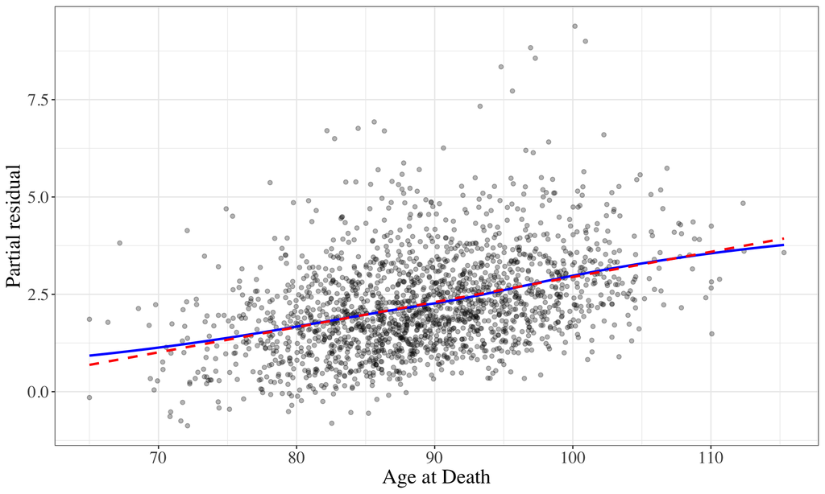

```r
X <- model.matrix(~ . - 1, data = as.data.frame(part_2_mod_clean$data$predictors))
beta <- part_2_mod_clean$parameters$beta
resid <- as.numeric(part_2_mod_clean$data$residuals)

partial_resid_plot <- function(j, var_name) {

  if (var_name == "Age at Death") add_val <- 65
  else add_val <- 0
  pr <- resid + X[, j] * beta[j]

  plot_dat <- data.frame(
    x = X[, j],
    pr = pr
  )

  ggplot(plot_dat, aes(x = x + add_val, y = pr)) +
    geom_point(alpha = 0.3) +
    geom_smooth(method = "loess", se = FALSE, color = "blue") +
    geom_smooth(method = "lm", se = FALSE, linetype = "dashed", color = "red") +
    labs(
      x = var_name,
      y = "Partial residual"
    ) +
    theme_bw() +
    theme(
      legend.position = "bottom",
      text = element_text(family = "Times"),
      strip.background = element_blank(),
      strip.text = element_text(size = 15),
      axis.text = element_text(size = 15),
      plot.title = element_text(hjust = 0.5, size = 20),
      axis.title = element_text(size = 18)
    )
}

# Example
partial_resid_plot(j = 1, var_name = "Age at Death")
```

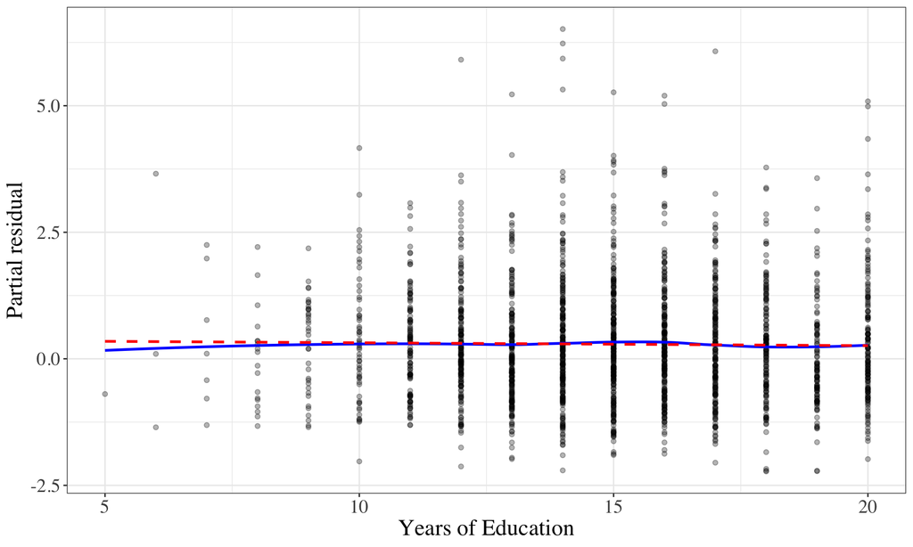

```r
partial_resid_plot(j = 2, var_name = "Years of Education")
```

### Cumulative Martingale Processes

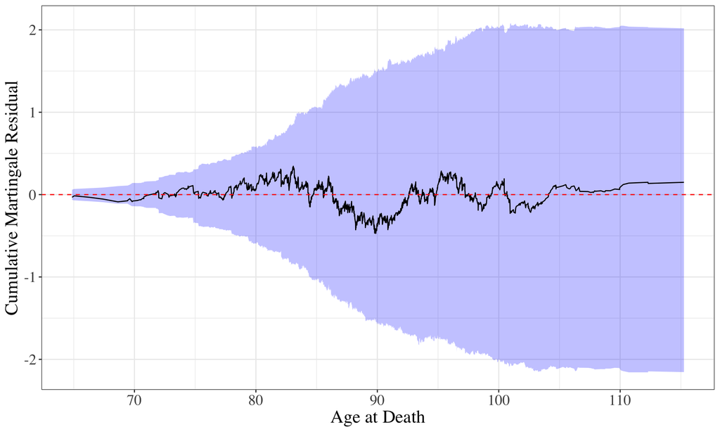

```r
cum_mart_resid_plot <- function(mart, x, x_label = "Age at Death") {
  n <- length(mart)

  # jitter if the variable is discrete
  if (length(x) != length(unique(x))) {
    x <- x + rnorm(length(x), 0, 0.1)
  }

  ord <- order(x)
  x_ord <- x[ord]
  m_ord <- mart[ord]

  R_obs <- cumsum(m_ord) / sqrt(n)

  B <- 1000
  R_sim <- matrix(NA_real_, nrow = n, ncol = B)

  for (b in seq_len(B)) {
    G <- rnorm(n)
    M_star <- m_ord * G
    R_sim[, b] <- cumsum(M_star) / sqrt(n)
  }

  lower <- apply(R_sim, 1, quantile, probs = 0.025)
  upper <- apply(R_sim, 1, quantile, probs = 0.975)

  if (x_label == "Age at Death") plot_x <- x_ord + 65
  else plot_x <- x_ord

  p <- ggplot() +
    geom_ribbon(
      aes(x = plot_x, ymin = lower, ymax = upper),
      fill = "blue",
      alpha = 0.25
    ) +
    geom_line(
      aes(x = plot_x, y = R_obs)
    ) +
    geom_hline(yintercept = 0, color = "red", lty = "dashed") +
    xlab(x_label) +
    ylab("Cumulative Martingale Residual") +
    theme_bw() +
    theme(
      legend.position = "bottom",
      text = element_text(family = "Times"),
      strip.background = element_blank(),
      strip.text = element_text(size = 15),
      axis.text = element_text(size = 15),
      axis.title = element_text(size = 18)
    )

  return(p)
}

martingale_resids <- part_2_mod_clean$data$martingale_residuals
cum_mart_resid_plot(martingale_resids, dem_mod_dat$t, x_label = "Age at Death")
```

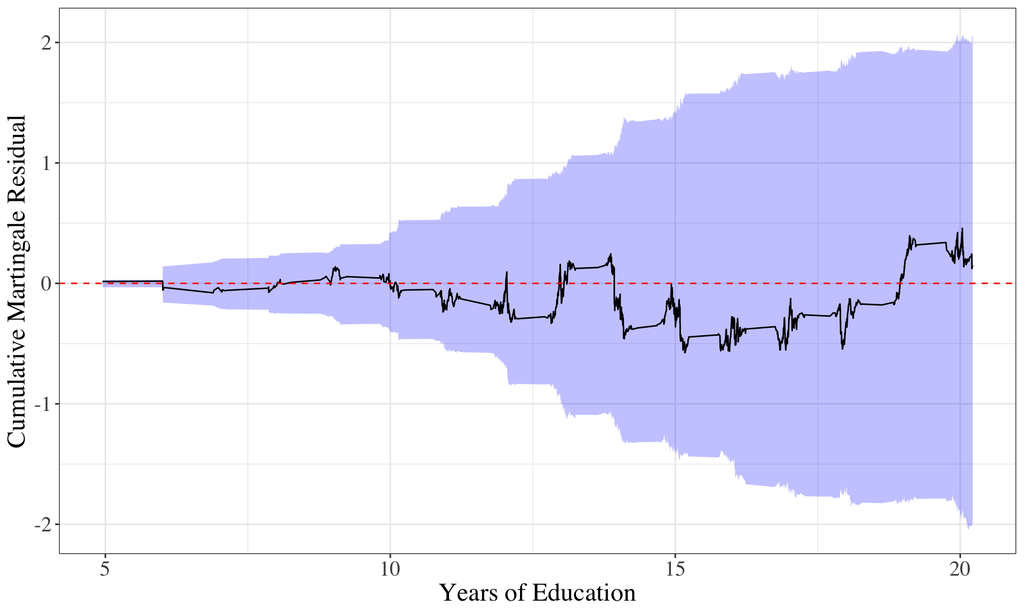

```r
cum_mart_resid_plot(martingale_resids, dem_mod_dat$years_education, x_label = "Years of Education")
```

### Influence Diagnostics

```r
# Identify high-leverage points and outliers
# Note: This is approximate - full dfbeta analysis requires custom implementation

cat("Part 2 Influence Diagnostics:\n\n")
```

```
## Part 2 Influence Diagnostics:
```

```r
# Leverage (hat values) - approximated using residuals
mart_resid <- part_2_mod_clean$data$martingale_residuals
leverage_approx <- abs(mart_resid) / sd(mart_resid)
high_leverage <- which(leverage_approx > 2.5)

cat("High leverage points (|standardized residual| > 2.5):", length(high_leverage), "\n")
```

```
## High leverage points (|standardized residual| > 2.5): 58
```

```r
cat("Proportion:", round(length(high_leverage) / length(mart_resid) * 100, 2), "%\n")
```

```
## Proportion: 3.1 %
```

```r
if (length(high_leverage) > 0 && length(high_leverage) < nrow(dem_mod_dat) * 0.1) {
  cat("\nRefitting model without high-leverage points...\n")

  dem_mod_dat_robust <- dem_mod_dat[-high_leverage, ]

  tic()
  part_2_mod_robust <- ltrc(
    survival::Surv(mod_y, got_dementia) ~ t + years_education + is_female +
      is_married + comorbidity + num_e4_1 + num_e4_2 + is_race_black + is_race_other,
    data = dem_mod_dat_robust,
    trunc_time = dem_mod_dat_robust$mod_l,
    n_start = 10,
    int_knots = 1
  )
  toc()

  part_2_mod_robust_clean <- get_clean_model(part_2_mod_robust)

  # Compare coefficients
  coef_comparison_p2 <- data.frame(
    Original = part_2_mod_clean$parameters$beta,
    Robust = part_2_mod_robust_clean$parameters$beta,
    Difference = part_2_mod_robust_clean$parameters$beta - part_2_mod_clean$parameters$beta,
    Pct_Change = (part_2_mod_robust_clean$parameters$beta - part_2_mod_clean$parameters$beta) /
                 part_2_mod_clean$parameters$beta * 100
  )

  cat("\nCoefficient comparison (original vs. robust):\n")
  print(round(coef_comparison_p2, 4))

  max_pct_change <- max(abs(coef_comparison_p2$Pct_Change))
  if (max_pct_change < 10) {
    cat("\n✓ Robust model similar (max change < 10%)\n")
  } else {
    cat("\n⚠ Substantial changes detected (max change > 10%)\n")
  }
} else {
  cat("\n⚠ Too many or too few high-leverage points for robust comparison\n")
}
```

```
##
## Refitting model without high-leverage points...
## 550.881 sec elapsed
##
## Coefficient comparison (original vs. robust):
##   Original  Robust Difference Pct_Change
## 1   0.0828  0.0777    -0.0051    -6.1347
## 2   0.0030 -0.0096    -0.0126  -423.4519
## 3  -0.1191 -0.1322    -0.0131    11.0273
## 4  -0.0276 -0.0295    -0.0019     6.8836
## 5   0.4628  0.4317    -0.0312    -6.7358
## 6  -0.4690 -0.4571     0.0120    -2.5518
## 7  -0.4219 -0.4262    -0.0042     1.0068
## 8  -0.2658 -0.2535     0.0122    -4.6056
## 9  -0.6698 -0.6235     0.0462    -6.8996
##
## ⚠ Substantial changes detected (max change > 10%)
```

These results are similar to what we had in this same analysis for the part 1 model. Some large changes but not relative to the standard error of the estimate. And the conclusion remains the same.

### Comparison to Parametric Model

```r
cat("Comparing semiparametric LTRC to parametric truncated regression...\n")

resids <- as.numeric(part_2_mod_clean$data$residuals)
# need to subtract the linear predictor to get the truncation time on the same scale as the residuals
trunc_points <- dem_mod_dat$mod_l - part_2_mod_clean$data$fitted_response
sum(trunc_points > resids) # sanity check

# Estimate parameters assuming truncated normal (MLE under truncation)
# Using method of moments as starting point, then refining
resid_mean_init <- mean(resids)
resid_sd_init <- sd(resids)

# Fit truncated normal via maximum likelihood
neg_loglik <- function(par, t, l) {
  mu <- par[1]
  sigma <- exp(par[2])

  z_t <- (t - mu) / sigma
  z_l <- (l - mu) / sigma

  ll <- sum(
    dnorm(z_t, log = TRUE) - log(sigma) -
      pnorm(z_l, lower.tail = FALSE, log.p = TRUE)
  )

  return(-ll)
}

# Optimize
fit_trunc <- optim(
  par = c(resid_mean_init, log(resid_sd_init)),
  fn = neg_loglik,
  t = resids,
  l = trunc_points,
  method = "BFGS"
)

mu_hat <- fit_trunc$par[1]
sigma_hat <- exp(fit_trunc$par[2])

cat("Fitted truncated normal parameters:\n")
cat("  mu =", round(mu_hat, 4), "\n")
cat("  sigma =", round(sigma_hat, 4), "\n\n")

# Transform residuals to uniform via truncated normal CDF, then to standard normal
# If residuals truly follow TruncNorm(mu, sigma, a=l_i), then z should be N(0,1)
u <- (pnorm((resids - mu_hat) / sigma_hat) - pnorm((trunc_points - mu_hat) / sigma_hat)) /
  (1 - pnorm((trunc_points - mu_hat) / sigma_hat))
z <- qnorm(u)

# Remove any infinite/NA values
z_clean <- z[is.finite(z)]

# Create QQ plot data for ggplot
n <- length(z_clean)
theoretical_quantiles <- qnorm(ppoints(n))
observed_sorted <- sort(z_clean)

qq_df <- data.frame(
  theoretical = theoretical_quantiles,
  observed = observed_sorted
)

# QQ Plot with ggplot
qq_trunc_plot <- ggplot(qq_df) +
  geom_point(aes(y = theoretical, x = observed), alpha = 0.3) +
  geom_abline(slope = 1, intercept = 0, color = "red", lty = "dashed", linewidth = 1) +
  labs(
    title = "Part 2: QQ Plot of Residuals vs. Truncated Normal",
    subtitle = "If residuals follow truncated normal, points should lie on the line",
    y = "Theoretical Quantiles (Standard Normal)",
    x = "Transformed Residuals"
  ) +
  theme_bw() +
  theme(
    legend.position = "bottom",
    text = element_text(family = "Times"),
    strip.background = element_blank(),
    strip.text = element_text(size = 15),
    axis.text = element_text(size = 15),
    axis.title = element_text(size = 18),
    plot.title = element_text(size = 16),
    plot.subtitle = element_text(size = 12)
  )

print(qq_trunc_plot)
```

[output not shown]

# 6. Sensitivity Analyses

## 6.1 ADRC Sub-Analysis

### Included vs. Excluded Subjects

```r
cat("ADRC Comparison Analysis\n")
```

```
## ADRC Comparison Analysis
```

```r
cat("========================\n\n")
cat("⚠ Note: With simulated data, subject-level characteristics are artificial\n")
```

```
## ⚠ Note: With simulated data, subject-level characteristics are artificial
```

```r
cat("  For real data, compare demographics of included vs. excluded subjects\n\n")
```

```
##   For real data, compare demographics of included vs. excluded subjects
```

```r
# With real data, would compare:
# - Age distributions
# - Sex ratios
# - Education levels
# - Dementia rates
# - Between those in the analysis vs. those excluded

cat("Analysis to perform with real NACC data:\n")
```

```
## Analysis to perform with real NACC data:
```

```r
cat("  1. Identify exclusion reasons (missing data, age < 65, etc.)\n")
```

```
##   1. Identify exclusion reasons (missing data, age < 65, etc.)
```

```r
cat("  2. Compare demographics: age, sex, education, race, APOE\n")
```

```
##   2. Compare demographics: age, sex, education, race, APOE
```

```r
cat("  3. Assess potential selection bias\n")
```

```
##   3. Assess potential selection bias
```

```r
cat("  4. Consider sensitivity to exclusion criteria\n")
```

```
##   4. Consider sensitivity to exclusion criteria
```

### Random Effects Models

Fit mixed-effects models with random intercepts and slopes by ADRC:

```r
cat("Fitting random effects models by ADRC...\n\n")
```

```
## Fitting random effects models by ADRC...
```

```r
# Load additional packages
library(statmod)
library(truncnorm)
library(TMB)

# Part 1: Random intercept logistic regression
cat("Part 1: Random intercept logistic model\n")
```

```
## Part 1: Random intercept logistic model
```

```r
cat("---------------------------------------\n")
tic()
part_1_re <- glmer(
  got_dementia ~ t + years_education + is_female + is_married + comorbidity +
    as.factor(num_e4) + is_race_black + is_race_other + l + (1 | adc),
  data = mod_dat,
  family = binomial
)
# This sometimes errors out, just try it a couple of times
toc()
```

```
## 1.398 sec elapsed
```

```r
summary(part_1_re)
```

```
## Generalized linear mixed model fit by maximum likelihood (Laplace
##   Approximation) [glmerMod]
##  Family: binomial  ( logit )
## Formula: got_dementia ~ t + years_education + is_female + is_married +
##     comorbidity + as.factor(num_e4) + is_race_black + is_race_other +
##     l + (1 | adc)
##    Data: mod_dat
##
##      AIC      BIC   logLik deviance df.resid
##   5725.3   5803.6  -2850.7   5701.3     5024
##
## Scaled residuals:
##     Min      1Q  Median      3Q     Max
## -5.9723 -0.6606 -0.4458  0.8397  3.3167
##
## Random effects:
##  Groups Name        Variance Std.Dev.
##  adc    (Intercept) 0        0
## Number of obs: 5036, groups:  adc, 38
##
## Fixed effects:
##                     Estimate Std. Error z value Pr(>|z|)
## (Intercept)        -1.953675   0.203918  -9.581  < 2e-16 ***
## t                   0.131372   0.005853  22.444  < 2e-16 ***
## years_education    -0.007527   0.010830  -0.695    0.487
## is_female          -0.098781   0.065166  -1.516    0.130
## is_married          0.438543   0.065681   6.677 2.44e-11 ***
## comorbidity         0.015368   0.071370   0.215    0.830
## as.factor(num_e4)1  0.526860   0.071803   7.338 2.18e-13 ***
## as.factor(num_e4)2  1.310537   0.148423   8.830  < 2e-16 ***
## is_race_black      -0.718665   0.112506  -6.388 1.68e-10 ***
## is_race_other      -0.183145   0.202042  -0.906    0.365
## l                  -0.135685   0.006165 -22.011  < 2e-16 ***
## ---
## Signif. codes:  0 '***' 0.001 '**' 0.01 '*' 0.05 '.' 0.1 ' ' 1
##
## Correlation of Fixed Effects:
##             (Intr) t      yrs_dc is_fml is_mrr cmrbdt a.(_4)1 a.(_4)2 is_rc_b
## t           -0.399
## years_edctn -0.810  0.015
## is_female   -0.188  0.016  0.021
## is_married  -0.198  0.017 -0.001  0.002
## comorbidity -0.131  0.000  0.037  0.001  0.005
## as.fct(_4)1 -0.134  0.048  0.003  0.057  0.035  0.008
## as.fct(_4)2 -0.050  0.033 -0.018  0.067  0.035 -0.002  0.162
## is_rac_blck  0.008 -0.046 -0.016 -0.133 -0.024  0.000 -0.077  -0.091
## is_race_thr -0.015  0.007 -0.013 -0.002  0.007 -0.014  0.000  -0.183   0.065
## l            0.066 -0.690 -0.003 -0.001 -0.022  0.000 -0.059  -0.051   0.048
##             is_rc_t
## t
## years_edctn
## is_female
## is_married
## comorbidity
## as.fct(_4)1
## as.fct(_4)2
## is_rac_blck
## is_race_thr
## l           -0.005
## optimizer (Nelder_Mead) convergence code: 0 (OK)
## boundary (singular) fit: see help('isSingular')
```

```r
# Extract fixed effects and random effects variance
fe_p1 <- fixef(part_1_re)
se_p1 <- sqrt(diag(vcov(part_1_re)))
re_var_p1 <- as.data.frame(VarCorr(part_1_re))

cat("\n\nPart 1 Random Effects Variance:\n")
```

```
##
##
## Part 1 Random Effects Variance:
```

```r
print(re_var_p1)
```

```
##   grp        var1 var2 vcov sdcor
## 1 adc (Intercept) <NA>    0     0
```

```r
# Part 2: Truncated regression with random effects
cat("\n\nPart 2: Truncated regression with random effects\n")
```

```
##
##
## Part 2: Truncated regression with random effects
```

```r
cat("------------------------------------------------\n")
cat("⚠ Note: This uses TMB for random slopes - may take 2-3 minutes\n\n")
```

```
## ⚠ Note: This uses TMB for random slopes - may take 2-3 minutes
```

```r
# First, fit basic truncated regression (no random effects) as baseline
library(truncreg)
fit_basic <- truncreg(
  mod_y ~ t + years_education + is_female + is_married + comorbidity +
    num_e4_1 + num_e4_2 + is_race_black + is_race_other,
  point = dem_mod_dat$mod_l,
  data = dem_mod_dat,
  direction = "left"
)

cat("Basic truncated regression (no random effects):\n")
```

```
## Basic truncated regression (no random effects):
```

```r
print(summary(fit_basic))
```

```
##
## Call:
## truncreg(formula = mod_y ~ t + years_education + is_female +
##     is_married + comorbidity + num_e4_1 + num_e4_2 + is_race_black +
##     is_race_other, data = dem_mod_dat, point = dem_mod_dat$mod_l,
##     direction = "left")
##
## BFGS maximization method
## 73 iterations, 0h:0m:0s
## g'(-H)^-1g = 1.52E-08
##
##
##
## Coefficients :
##                   Estimate Std. Error t-value  Pr(>|t|)
## (Intercept)      0.0932063  0.2377086  0.3921    0.6950
## t                0.0848203  0.0049402 17.1696 < 2.2e-16 ***
## years_education -0.0099674  0.0123426 -0.8076    0.4193
## is_female       -0.1475852  0.0747033 -1.9756    0.0482 *
## is_married      -0.0997280  0.0759104 -1.3138    0.1889
## comorbidity      0.4816746  0.0795400  6.0558 1.398e-09 ***
## num_e4_1        -0.4882196  0.0823608 -5.9278 3.070e-09 ***
## num_e4_2        -0.5697121  0.1420100 -4.0118 6.026e-05 ***
## is_race_black   -0.3490279  0.1420456 -2.4572    0.0140 *
## is_race_other   -0.6444826  0.2321484 -2.7762    0.0055 **
## sigma            1.3279495  0.0286691 46.3199 < 2.2e-16 ***
## ---
## Signif. codes:  0 '***' 0.001 '**' 0.01 '*' 0.05 '.' 0.1 ' ' 1
##
## Log-Likelihood: -2667.1 on 11 Df
```

```r
# Now fit truncated LMM with random intercept and slopes using TMB
cat("\n\nFitting truncated LMM with random effects using TMB...\n")
```

```
##
##
## Fitting truncated LMM with random effects using TMB...
```

```r
# Compile TMB model
cpp_file <- "model/truncated_lmm.cpp"
if (file.exists(cpp_file)) {
  cat("Compiling TMB model...\n")
  TMB::compile(cpp_file)
  dyn.load(dynlib("model/truncated_lmm"))

  # Construct fixed and random effects design matrices
  X <- model.matrix(~ t + years_education + is_female + is_married +
                      comorbidity + num_e4_1 + num_e4_2 +
                      is_race_black + is_race_other, data = dem_mod_dat)

  # Random effects: intercept + selected covariates
  Z <- model.matrix(~ is_female + is_married + comorbidity +
                      num_e4_1 + num_e4_2 + is_race_black + is_race_other,
                    data = dem_mod_dat)

  # Add random intercept as first column
  Z <- cbind(1, Z)

  # Map subjects to 0-based index for TMB
  id <- as.integer(as.factor(dem_mod_dat$adc)) - 1

  # Prepare data for TMB
  data <- list(
    y = dem_mod_dat$mod_y,
    X = X,
    Z = Z,
    id = id,
    L = dem_mod_dat$mod_l
  )

  # Starting values
  p <- ncol(X)
  q <- ncol(Z)
  n_subj <- length(unique(id))

  parameters <- list(
    beta = rep(0, p),
    log_sigma = 0,
    b_raw = rep(0, n_subj * q),
    log_sd_b = rep(0, q)
  )

  # Create objective function
  tic()
  obj <- MakeADFun(data, parameters, random = "b_raw", DLL = "truncated_lmm")

  # Optimize
  opt <- nlminb(obj$par, obj$fn, obj$gr)

  # Get standard errors
  rep <- sdreport(obj)
  toc()

  cat("\n\nPart 2 Random Effects Model Results:\n")
  print(summary(rep))

  # Store results
  part_2_re <- list(
    opt = opt,
    report = rep,
    obj = obj
  )

} else {
  cat("⚠ TMB model file not found at:", cpp_file, "\n")
  cat("  Skipping random effects model for Part 2\n")
  part_2_re <- NULL
}
```

[output not shown]

[output cut: 922 more lines]

[output not shown]

### Table S.4 and S.5

Generate supplementary tables for ADRC analysis:

```r
# Table S.4: Part 1 Random Effects Summary
cat("\n\nTable S.4: Part 1 Model - Fixed Effects and Random Effects Variance\n")
```

```
##
##
## Table S.4: Part 1 Model - Fixed Effects and Random Effects Variance
```

```r
cat("====================================================================\n\n")
# Fixed effects
fe_p1 <- fixef(part_1_re)
se_p1 <- sqrt(diag(vcov(part_1_re)))

table_s4 <- data.frame(
  Covariate = names(fe_p1),
  Estimate = round(fe_p1, 3),
  SE = round(se_p1, 3),
  Z = round(fe_p1 / se_p1, 3),
  P_value = format.pval(2 * pnorm(-abs(fe_p1 / se_p1)), digits = 3, eps = 0.001)
)

print(table_s4)
```

```
##                             Covariate Estimate    SE       Z P_value
## (Intercept)               (Intercept)   -1.954 0.204  -9.581  <0.001
## t                                   t    0.131 0.006  22.444  <0.001
## years_education       years_education   -0.008 0.011  -0.695   0.487
## is_female                   is_female   -0.099 0.065  -1.516   0.130
## is_married                 is_married    0.439 0.066   6.677  <0.001
## comorbidity               comorbidity    0.015 0.071   0.215   0.830
## as.factor(num_e4)1 as.factor(num_e4)1    0.527 0.072   7.338  <0.001
## as.factor(num_e4)2 as.factor(num_e4)2    1.311 0.148   8.830  <0.001
## is_race_black           is_race_black   -0.719 0.113  -6.388  <0.001
## is_race_other           is_race_other   -0.183 0.202  -0.906   0.365
## l                                   l   -0.136 0.006 -22.011  <0.001
```

```r
# Random effects variance
cat("\n\nRandom Effects Variance (ADRC) for Part 1:\n")
```

```
##
##
## Random Effects Variance (ADRC) for Part 1:
```

```r
print(re_var_p1)
```

```
##   grp        var1 var2 vcov sdcor
## 1 adc (Intercept) <NA>    0     0
```

```r
# Table S.5: Part 2 Random Effects Summary
cat("\n\nTable S.5: Part 2 Model - Fixed Effects and Random Effects Variance\n")
```

```
##
##
## Table S.5: Part 2 Model - Fixed Effects and Random Effects Variance
```

```r
cat("====================================================================\n\n")
if (!is.null(part_2_re)) {
  # Extract results from TMB sdreport
  rep_summary <- summary(part_2_re$report, "fixed")

  # Beta coefficients (fixed effects)
  beta_idx <- grep("beta", rownames(rep_summary))
  beta_results <- rep_summary[beta_idx, ]

  # Create covariate names
  covariate_names <- c("(Intercept)", "t", "years_education", "is_female",
                      "is_married", "comorbidity", "num_e4_1", "num_e4_2",
                      "is_race_black", "is_race_other")

  table_s5 <- data.frame(
    Covariate = covariate_names,
    Estimate = round(beta_results[, "Estimate"], 3),
    SE = round(beta_results[, "Std. Error"], 3),
    Z = round(beta_results[, "Estimate"] / beta_results[, "Std. Error"], 3),
    P_value = format.pval(2 * pnorm(-abs(beta_results[, "Estimate"] /
                                         beta_results[, "Std. Error"])),
                         digits = 3, eps = 0.001)
  )

  print(table_s5)

  # Random effects standard deviations
  cat("\n\nRandom Effects Standard Deviations (ADRC) for Part 2:\n")
  sd_b_idx <- grep("log_sd_b", rownames(rep_summary))
  sd_b_results <- exp(rep_summary[sd_b_idx, "Estimate"])
  names(sd_b_results) <- c("Intercept", "is_female", "is_married", "comorbidity",
                          "num_e4_1", "num_e4_2", "is_race_black", "is_race_other")
  print(round(sd_b_results, 4))

  # Residual standard deviation
  cat("\n\nResidual Standard Deviation:\n")
  sigma_idx <- grep("log_sigma", rownames(rep_summary))
  sigma <- exp(rep_summary[sigma_idx, "Estimate"])
  cat("  σ =", round(sigma, 4), "\n")

} else {
  cat("⚠ Part 2 random effects model not available (TMB compilation failed)\n")
}
```

```
##          Covariate Estimate    SE      Z P_value
## 1      (Intercept)    0.085 0.237  0.360  0.7192
## 2                t    0.085 0.005 17.145  <0.001
## 3  years_education   -0.009 0.012 -0.747  0.4550
## 4        is_female   -0.137 0.075 -1.829  0.0675
## 5       is_married   -0.096 0.077 -1.238  0.2158
## 6      comorbidity    0.481 0.079  6.077  <0.001
## 7         num_e4_1   -0.485 0.082 -5.919  <0.001
## 8         num_e4_2   -0.555 0.142 -3.897  <0.001
## 9    is_race_black   -0.353 0.141 -2.504  0.0123
## 10   is_race_other   -0.761 0.303 -2.514  0.0120
##
##
## Random Effects Standard Deviations (ADRC) for Part 2:
##     Intercept     is_female    is_married   comorbidity      num_e4_1
##        0.0000        0.0000        0.0000        0.0996        0.0000
##      num_e4_2 is_race_black is_race_other          <NA>
##        0.0007        0.0000        0.0000        0.9030
##
##
## Residual Standard Deviation:
##   σ = 1.3196
```

```r
# Likelihood ratio test: Random effects vs. fixed effects
cat("\n\nLikelihood Ratio Test: Random vs. Fixed Effects\n")
```

```
##
##
## Likelihood Ratio Test: Random vs. Fixed Effects
```

```r
cat("================================================\n\n")
cat("Part 1 (logistic regression):\n")
```

```
## Part 1 (logistic regression):
```

```r
# Compare to fixed effects only model
lrt_p1 <- anova(part_1_mod, part_1_re)
print(lrt_p1)
```

```
## Analysis of Deviance Table
##
## Model: binomial, link: logit
##
## Response: got_dementia
##
## Terms added sequentially (first to last)
##
##
##                   Df Deviance Resid. Df Resid. Dev
## NULL                               5035     6646.2
## t                  1   157.12      5034     6489.1
## years_education    1     0.64      5033     6488.4
## is_female          1    12.90      5032     6475.5
## is_married         1    49.66      5031     6425.9
## comorbidity        1     0.05      5030     6425.8
## as.factor(num_e4)  2   108.75      5028     6317.1
## is_race_black      1    42.23      5027     6274.8
## is_race_other      1     1.16      5026     6273.7
## l                  1   572.38      5025     5701.3
```

```r
if (!is.null(part_2_re)) {
  cat("\n\nPart 2 (truncated regression):\n")
  # Compare to basic truncated regression
  loglik_fixed <- logLik(fit_basic)
  loglik_random <- -part_2_re$opt$objective

  lr_stat <- 2 * (loglik_random - as.numeric(loglik_fixed))
  df_diff <- ncol(Z)  # Number of random effect standard deviations
  p_value <- pchisq(lr_stat, df = df_diff, lower.tail = FALSE)

  cat("Log-likelihood (fixed effects only):", round(as.numeric(loglik_fixed), 2), "\n")
  cat("Log-likelihood (random effects):", round(loglik_random, 2), "\n")
  cat("LR statistic:", round(lr_stat, 2), "\n")
  cat("df:", df_diff, "\n")
  cat("p-value:", format.pval(p_value, digits = 3, eps = 0.001), "\n")

  if (p_value < 0.05) {
    cat("\n✓ Random effects significantly improve model fit (p < 0.05)\n")
  } else {
    cat("\nℹ Random effects do not significantly improve fit (p ≥ 0.05)\n")
  }
}
```

```
##
##
## Part 2 (truncated regression):
## Log-likelihood (fixed effects only): -2667.15
## Log-likelihood (random effects): -2665.7
## LR statistic: 2.89
## df: 9
## p-value: 0.969
##
## ℹ Random effects do not significantly improve fit (p ≥ 0.05)
```

## 6.2 Temporal Sampling Sub-Analysis

Use `death_year` to simulate historical analyses:

NOTE: This will take about 15 minutes to run

```r
cat("Temporal Sampling Sensitivity Analysis\n")
```

```
## Temporal Sampling Sensitivity Analysis
```

```r
cat("======================================\n\n")
```

```r
if (!"death_year" %in% names(mod_dat)) {
  cat("⚠ death_year column not found in data\n")
  cat("  This analysis requires simulated death years\n")
} else {
  cat("Analyzing model stability across different observation periods...\n\n")

  # Define historical cutoff years
  # Include 2015 for Table S.7
  cutoff_years <- c(2010, 2015, 2020)

  temporal_results <- list()

  for (year in cutoff_years) {
    cat("Fitting models as if data collection stopped in", year, "...\n")

    # Filter data
    historical_data <- mod_dat %>% filter(death_year <= year)

    cat("  Sample size:", nrow(historical_data), "\n")

    # Fit Part 1
    part_1_historical <- glm(
      got_dementia ~ t + years_education + is_female + is_married + comorbidity +
        as.factor(num_e4) + is_race_black + is_race_other + l,
      data = historical_data,
      family = "binomial"
    )

    # Fit Part 2
    dem_historical <- historical_data %>%
      filter(got_dementia == 1) %>%
      mutate(num_e4_1 = ifelse(num_e4 == 1, 1, 0),
             num_e4_2 = ifelse(num_e4 == 2, 1, 0))

    if (nrow(dem_historical) > 50) {  # Need sufficient sample
      part_2_historical <- ltrc(
        survival::Surv(mod_y, got_dementia) ~ t + years_education + is_female +
          is_married + comorbidity + num_e4_1 + num_e4_2 + is_race_black + is_race_other,
        data = dem_historical,
        trunc_time = dem_historical$mod_l,
        n_start = 10,
        int_knots = 1
      )

      part_2_historical_clean <- get_clean_model(part_2_historical)

      # Calculate standard errors and CIs
      part1_se <- summary(part_1_historical)$coef[, 2]
      part1_lower <- coef(part_1_historical) - 1.96 * part1_se
      part1_upper <- coef(part_1_historical) + 1.96 * part1_se

      part2_se <- sqrt(diag(vcov(part_2_historical_clean)))
      part2_lower <- part_2_historical_clean$parameters$beta - 1.96 * part2_se
      part2_upper <- part_2_historical_clean$parameters$beta + 1.96 * part2_se

      # Store coefficients and CIs
      temporal_results[[as.character(year)]] <- list(
        year = year,
        n = nrow(historical_data),
        n_dementia = nrow(dem_historical),
        part1_coef = coef(part_1_historical),
        part2_coef = part_2_historical_clean$parameters$beta,
        part1_lower = part1_lower,
        part1_upper = part1_upper,
        part2_lower = part2_lower,
        part2_upper = part2_upper
      )
    }

    cat("\n")
  }

  # Compare coefficients over time
  cat("\nCoefficient Stability Analysis:\n")
  cat("================================\n\n")

  # Part 1 comparison
  cat("Part 1 Coefficients Across Years:\n")
  part1_comparison <- sapply(temporal_results, function(x) x$part1_coef[-1])  # Exclude intercept
  colnames(part1_comparison) <- sapply(temporal_results, function(x) x$year)
  print(round(part1_comparison, 3))

  # Part 2 comparison
  cat("\n\nPart 2 Coefficients Across Years:\n")
  part2_comparison <- sapply(temporal_results, function(x) x$part2_coef)
  colnames(part2_comparison) <- sapply(temporal_results, function(x) x$year)
  print(round(part2_comparison, 3))
}
```

```
## Analyzing model stability across different observation periods...
##
## Fitting models as if data collection stopped in 2010 ...
##   Sample size: 1422
##
## Fitting models as if data collection stopped in 2015 ...
##   Sample size: 2707
##
## Fitting models as if data collection stopped in 2020 ...
##   Sample size: 4009
##
##
## Coefficient Stability Analysis:
## ================================
##
## Part 1 Coefficients Across Years:
##                      2010   2015   2020
## t                   0.126  0.129  0.129
## years_education    -0.019  0.001  0.000
## is_female          -0.037 -0.110 -0.123
## is_married          0.326  0.522  0.475
## comorbidity        -0.079  0.015  0.002
## as.factor(num_e4)1  0.541  0.464  0.512
## as.factor(num_e4)2  1.311  1.391  1.217
## is_race_black      -0.757 -0.729 -0.675
## is_race_other      -0.411 -0.202 -0.144
## l                  -0.132 -0.128 -0.133
##
##
## Part 2 Coefficients Across Years:
##         2010   2015   2020
##  [1,]  0.073  0.080  0.083
##  [2,] -0.001 -0.014  0.012
##  [3,] -0.110 -0.209 -0.176
##  [4,] -0.103 -0.060 -0.069
##  [5,]  0.402  0.526  0.530
##  [6,] -0.538 -0.494 -0.466
##  [7,] -0.413 -0.497 -0.553
##  [8,] -0.212 -0.242 -0.325
##  [9,] -1.030 -0.638 -0.687
```

### Figure S.6: Temporal Stability

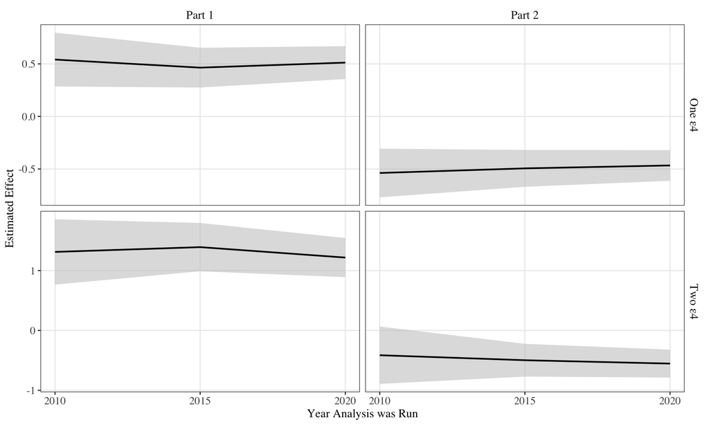

```r
if (exists("temporal_results") && length(temporal_results) > 0) {
  # Extract ε4 covariate results (one and two alleles)
  temporal_df <- data.frame()

  for (i in seq_along(temporal_results)) {
    res <- temporal_results[[i]]

    # Part 1: as.factor(num_e4)1 and as.factor(num_e4)2 (positions 7 and 8)
    # Part 2: num_e4_1 and num_e4_2 (positions 6 and 7)

    year_data <- data.frame(
      cutoff_year = as.Date(paste0(res$year, "-01-01")),
      model = rep(c("Part 1", "Part 2"), each = 2),
      label = rep(c("One ε4", "Two ε4"), 2),
      estimate = c(res$part1_coef[7:8], res$part2_coef[6:7]),
      ci_lower = c(res$part1_lower[7:8], res$part2_lower[6:7]),
      ci_upper = c(res$part1_upper[7:8], res$part2_upper[6:7])
    )

    temporal_df <- bind_rows(temporal_df, year_data)
  }

  # Create plot matching paper format
  fig_s6 <- temporal_df %>%
    ggplot() +
    geom_ribbon(
      aes(x = cutoff_year, ymin = ci_lower, ymax = ci_upper),
      fill = "gray", alpha = 0.5
    ) +
    geom_line(
      aes(x = cutoff_year, y = estimate),
      linewidth = 0.8
    ) +
    facet_grid(label ~ model, scales = "free_y") +
    labs(
      x = "Year Analysis was Run",
      y = "Estimated Effect"
    ) +
    theme_bw() +
    theme(
      legend.position = "none",
      text = element_text(family = "Times"),
      strip.background = element_blank(),
      strip.text = element_text(size = 12),
      axis.text = element_text(size = 11),
      axis.title = element_text(size = 12),
      panel.grid.minor = element_blank()
    )

  print(fig_s6)

  # Save
  ggsave(fs::path(RESULTS_DIR, "figure_s6_temporal_stability.png"),
         fig_s6, width = 10, height = 6, dpi = 300)
}
```

### Table S.7: Temporal Analysis (2015 Model Results)

```r
if (exists("temporal_results") && length(temporal_results) > 0) {
  # Extract 2015 results
  res_2015 <- temporal_results[["2015"]]

  if (!is.null(res_2015)) {
    cat("\n2015 Temporal Model Summary:\n")
    cat("  Sample Size:", res_2015$n, "\n")
    cat("  Dementia Cases:", res_2015$n_dementia, "\n")
    cat("  % Dementia:", round(res_2015$n_dementia / res_2015$n * 100, 1), "%\n\n")

    # Part 1: Extract coefficients (excluding intercept)
    part1_coef <- res_2015$part1_coef[-1]
    part1_lower <- res_2015$part1_lower[-1]
    part1_upper <- res_2015$part1_upper[-1]
    part1_se <- (part1_upper - part1_lower) / (2 * 1.96)
    part1_z <- part1_coef / part1_se

    # Part 2: Extract coefficients
    part2_coef <- res_2015$part2_coef
    part2_lower <- res_2015$part2_lower
    part2_upper <- res_2015$part2_upper
    part2_se <- (part2_upper - part2_lower) / (2 * 1.96)
    part2_z <- part2_coef / part2_se

    # Create table matching Table 2 format
    table_s7 <- data.frame(
      Covariate = c("t (time since age 65)", "Years of education", "Female",
                    "Married", "≥1 Comorbidity", "1 ε4 allele", "2 ε4 alleles",
                    "Black race", "Other race", "l (left truncation)"),
      Part1_Est = round(part1_coef, 3),
      Part1_CI = paste0("(", round(part1_lower, 3), ", ", round(part1_upper, 3), ")"),
      Part1_P = format.pval(2 * pnorm(-abs(part1_z)), digits = 3, eps = 0.001),
      Part2_Est = c(round(part2_coef, 3), "—"),
      Part2_CI = c(paste0("(", round(part2_lower, 3), ", ", round(part2_upper, 3), ")"), "—"),
      Part2_P = c(format.pval(2 * pnorm(-abs(part2_z)), digits = 3, eps = 0.001), "—")
    )

    knitr::kable(
      table_s7,
      caption = "Table S.7: Two-Part Model Coefficients (2015 Temporal Cutoff)",
      col.names = c("Covariate", "Estimate", "95% CI", "P-value",
                    "Estimate", "95% CI", "P-value"),
      align = c("l", "r", "l", "r", "r", "l", "r")
    )
  } else {
    cat("⚠ 2015 results not found in temporal_results.\n")
    cat("  Make sure cutoff_years includes 2015.\n")
  }
} else {
  cat("⚠ Temporal analysis results not available.\n")
}
```

```
##
## 2015 Temporal Model Summary:
##   Sample Size: 2707
##   Dementia Cases: 1006
##   % Dementia: 37.2 %
```

Table S.7: Two-Part Model Coefficients (2015 Temporal Cutoff)

|  | Covariate | Estimate | 95% CI | P-value | Estimate | 95% CI | P-value |
| --- | --- | --- | --- | --- | --- | --- | --- |
| t | t (time since age 65) | 0.129 | (0.114, 0.145) | <0.001 | 0.08 | (0.069, 0.091) | <0.001 |
| years_education | Years of education | 0.001 | (-0.028, 0.03) | 0.947 | -0.014 | (-0.04, 0.012) | 0.2798 |
| is_female | Female | -0.110 | (-0.283, 0.064) | 0.215 | -0.209 | (-0.363, -0.056) | 0.0076 |
| is_married | Married | 0.522 | (0.345, 0.698) | <0.001 | -0.06 | (-0.215, 0.096) | 0.4525 |
| comorbidity | ≥1 Comorbidity | 0.015 | (-0.176, 0.205) | 0.879 | 0.526 | (0.359, 0.692) | <0.001 |
| as.factor(num_e4)1 | 1 ε4 allele | 0.464 | (0.275, 0.654) | <0.001 | -0.494 | (-0.669, -0.319) | <0.001 |
| as.factor(num_e4)2 | 2 ε4 alleles | 1.391 | (0.988, 1.795) | <0.001 | -0.497 | (-0.77, -0.223) | <0.001 |
| is_race_black | Black race | -0.729 | (-1.036, -0.422) | <0.001 | -0.242 | (-0.575, 0.091) | 0.1541 |
| is_race_other | Other race | -0.202 | (-0.735, 0.332) | 0.459 | -0.638 | (-1.16, -0.115) | 0.0168 |
| l | l (left truncation) | -0.128 | (-0.144, -0.111) | <0.001 | — | — | — |

## 6.3 Weighted Analysis

Fit models with inverse probability weighting:

```r
weights_3 <- list(
  num_e4 = 0:2,
  is_race_black = 0:1,
  is_race_other = 0:1,
  is_female = 0:1
) %>%
  expand.grid() %>%
  filter(!(is_race_black == 1 & is_race_other == 1)) %>%
  arrange(num_e4, is_race_black, is_race_other, is_female) %>%
  mutate(
    obs_props = mod_dat %>% group_by(num_e4, is_race_black, is_race_other, is_female) %>% summarize(n = n(), pct = n() / nrow(.)) %>% pull(pct),
    pop_props = c(
      0.267784, # num_e4: 0 | race: white | sex: male
      0.267784, # num_e4: 0 | race: white | sex: female
      0.04117, # num_e4: 0 | race: other | sex: male
      0.04117, # num_e4: 0 | race: other | sex: female
      0.049046, # num_e4: 0 | race: black | sex: male
      0.049046, # num_e4: 0 | race: black | sex: female
      0.097614, # num_e4: 1 | race: white | sex: male
      0.097614, # num_e4: 1 | race: white | sex: female
      0.0150075, # num_e4: 1 | race: other | sex: male
      0.0150075, # num_e4: 1 | race: other | sex: female
      0.0178785, # num_e4: 1 | race: black | sex: male
      0.0178785, # num_e4: 1 | race: black | sex: female
      0.008602, # num_e4: 2 | race: white | sex: male
      0.008602, # num_e4: 2 | race: white | sex: female
      0.0013225, # num_e4: 2 | race: other | sex: male
      0.0013225, # num_e4: 2 | race: other | sex: female
      0.0015755, # num_e4: 2 | race: black | sex: male
      0.0015755  # num_e4: 2 | race: black | sex: female
    ),
    weight = pop_props / obs_props
  ) %>%
  select(-obs_props, -pop_props)


mod_dat <- mod_dat %>%
  left_join(weights_3, by = c("num_e4", "is_race_black", "is_race_other", "is_female"))

part_1_mod <- glm(
  got_dementia ~ t + years_education + is_female + is_married + comorbidity + is_race_black + is_race_other + as.factor(num_e4) + l,
  data = mod_dat,
  family = "binomial",
  weights = mod_dat$weight
)
summary(part_1_mod)
```

```
##
## Call:
## glm(formula = got_dementia ~ t + years_education + is_female +
##     is_married + comorbidity + is_race_black + is_race_other +
##     as.factor(num_e4) + l, family = "binomial", data = mod_dat,
##     weights = mod_dat$weight)
##
## Coefficients:
##                     Estimate Std. Error z value Pr(>|z|)
## (Intercept)        -1.958282   0.206108  -9.501  < 2e-16 ***
## t                   0.128304   0.005824  22.028  < 2e-16 ***
## years_education    -0.006823   0.010962  -0.622  0.53366
## is_female          -0.075891   0.065026  -1.167  0.24317
## is_married          0.408799   0.066309   6.165 7.05e-10 ***
## comorbidity         0.024349   0.071527   0.340  0.73354
## is_race_black      -0.720870   0.103613  -6.957 3.47e-12 ***
## is_race_other      -0.280070   0.108009  -2.593  0.00951 **
## as.factor(num_e4)1  0.528035   0.072480   7.285 3.21e-13 ***
## as.factor(num_e4)2  1.307718   0.211001   6.198 5.73e-10 ***
## l                  -0.130818   0.006076 -21.530  < 2e-16 ***
## ---
## Signif. codes:  0 '***' 0.001 '**' 0.01 '*' 0.05 '.' 0.1 ' ' 1
##
## (Dispersion parameter for binomial family taken to be 1)
##
##     Null deviance: 6526.8  on 5035  degrees of freedom
## Residual deviance: 5624.1  on 5025  degrees of freedom
## AIC: 6184.3
##
## Number of Fisher Scoring iterations: 4
```

```r
# note that standard errors are not correct here, need to use sandwich estimator if you want to do inference
vcov_robust <- vcovHC(part_1_mod, type = "HC0")
coeftest(part_1_mod, vcov = vcov_robust)
```

```
##
## z test of coefficients:
##
##                      Estimate Std. Error  z value  Pr(>|z|)
## (Intercept)        -1.9582820  0.2456048  -7.9733 1.545e-15 ***
## t                   0.1283037  0.0079885  16.0610 < 2.2e-16 ***
## years_education    -0.0068233  0.0132132  -0.5164    0.6056
## is_female          -0.0758911  0.0781958  -0.9705    0.3318
## is_married          0.4087989  0.0798632   5.1187 3.076e-07 ***
## comorbidity         0.0243495  0.0889672   0.2737    0.7843
## is_race_black      -0.7208705  0.1248667  -5.7731 7.782e-09 ***
## is_race_other      -0.2800696  0.2444396  -1.1458    0.2519
## as.factor(num_e4)1  0.5280348  0.0849997   6.2122 5.225e-10 ***
## as.factor(num_e4)2  1.3077177  0.1462538   8.9414 < 2.2e-16 ***
## l                  -0.1308178  0.0086738 -15.0819 < 2.2e-16 ***
## ---
## Signif. codes:  0 '***' 0.001 '**' 0.01 '*' 0.05 '.' 0.1 ' ' 1
```

```r
dem_mod_dat <- mod_dat %>%
  filter(got_dementia == 1) %>%
  mutate(
    num_e4_1 = ifelse(num_e4 == 1, 1, 0),
    num_e4_2 = ifelse(num_e4 == 2, 1, 0)
  )

tictoc::tic()
part_2_mod <- ltrc(
  survival::Surv(mod_y, got_dementia) ~ t + years_education + is_female + is_married + comorbidity + is_race_black + is_race_other + num_e4_1 + num_e4_2,
  data = dem_mod_dat, trunc_time = dem_mod_dat$mod_l, n_start = 10, int_knots = 1, weights = dem_mod_dat$weight
)
tictoc::toc()
```

```
## 555.712 sec elapsed
```

```r
part_2_mod_clean <- get_clean_model(part_2_mod)
part_2_mod_clean$parameters$beta
```

```
## [1]  0.097613239  0.008132264 -0.078704130  0.034416420  0.491153413
## [6] -0.303733149 -0.817341372 -0.442078346 -0.417456244
```

```r
vcov(part_2_mod_clean) %>% diag() %>% sqrt()
```

```
## [1] 0.004298025 0.010418310 0.061596413 0.063631285 0.065152210 0.126567265
## [7] 0.210212125 0.069012736 0.113090274
```

```r
readr::write_rds(part_2_mod_clean, fs::path(DATA_DIR, "weighted_pt_2_mod.rds"))
```

### Table S.8: Weighted Analysis Results

```r
cat("Part 1 Model - Weighted Analysis Results\n")
```

```
## Part 1 Model - Weighted Analysis Results
```

```r
# CI
beta <- coef(part_1_mod)
se <- sqrt(diag(vcov_robust))
cbind(
  est = beta,
  lower = beta - 1.96 * se,
  upper = beta + 1.96 * se
)
```

```
##                             est       lower       upper
## (Intercept)        -1.958281971 -2.43966739 -1.47689655
## t                   0.128303667  0.11264612  0.14396121
## years_education    -0.006823323 -0.03272114  0.01907450
## is_female          -0.075891057 -0.22915485  0.07737274
## is_married          0.408798894  0.25226712  0.56533067
## comorbidity         0.024349469 -0.15002626  0.19872520
## is_race_black      -0.720870462 -0.96560913 -0.47613180
## is_race_other      -0.280069600 -0.75917118  0.19903198
## as.factor(num_e4)1  0.528034799  0.36143531  0.69463429
## as.factor(num_e4)2  1.307717742  1.02106020  1.59437529
## l                  -0.130817837 -0.14781855 -0.11381713
```

```r
cat("\n\nPart 2 Model - Weighted Analysis Results\n")
```

```
##
##
## Part 2 Model - Weighted Analysis Results
```

```r
test_mod <- readr::read_rds(fs::path(DATA_DIR, "weighted_pt_2_mod.rds"))
beta <- test_mod$parameters$beta
se <- sqrt(diag(vcov(test_mod)))
cbind(
  est = beta,
  lower = beta - 1.96 * se,
  upper = beta + 1.96 * se
)
```

```
##                est       lower       upper
##  [1,]  0.097613239  0.08918911  0.10603737
##  [2,]  0.008132264 -0.01228762  0.02855215
##  [3,] -0.078704130 -0.19943310  0.04202484
##  [4,]  0.034416420 -0.09030090  0.15913374
##  [5,]  0.491153413  0.36345508  0.61885174
##  [6,] -0.303733149 -0.55180499 -0.05566131
##  [7,] -0.817341372 -1.22935714 -0.40532561
##  [8,] -0.442078346 -0.57734331 -0.30681338
##  [9,] -0.417456244 -0.63911318 -0.19579931
```

# 7. Simulation Study

This section demonstrates the simulation methodology used in the paper to validate the GHI estimation procedure. The simulation follows the exact code from `01_code_for_simulation_on_server.R`, omitting the bootstrap variance calculation since it is too time intensive. That code can be seen in the original file, and run following the instructions in the section on running the simulation on a server.

## Simulation Setup

```r
cat("GHI Model Validation via Simulation\n")
```

```
## GHI Model Validation via Simulation
```

```r
cat("====================================\n\n")
# Set true parameter values (used in paper)
alpha <- c(1.7, 0.05, 0.05)    # For generating t: log(t) ~ alpha[1] + alpha[2]*x_1 + alpha[3]*x_2
beta <- c(-0.1, -0.5, 2, 0.2)  # Part 1 coefficients: t, x_1, x_2, l
omega <- c(0, -0.1, 1, -1)     # Part 2 coefficients: intercept, t, x_1, x_2

cat("True parameters:\n")
```

```
## True parameters:
```

```r
cat("  α (t generation):", alpha, "\n")
```

```
##   α (t generation): 1.7 0.05 0.05
```

```r
cat("  β (Part 1 model):", beta, "\n")
```

```
##   β (Part 1 model): -0.1 -0.5 2 0.2
```

```r
cat("  ω (Part 2 model):", omega, "\n\n")
```

```
##   ω (Part 2 model): 0 -0.1 1 -1
```

```r
# Define prediction grid for GHI estimates
covariate_grid <- list(
  t = 7:12,                          # Age at death - 65
  x_1 = seq(-1.5, 1.5, by = 0.25),  # Continuous covariate
  x_2 = c(0, 1),                     # Binary covariate
  l = 1                              # Left truncation (age at entry - 65)
) %>%
  expand.grid() %>%
  mutate(
    l_over_t = l / t,
    eps_lower = log(l_over_t / (1 - l_over_t)) - omega[2] * t - omega[3] * x_1 - omega[4] * x_2
  )

cat("Prediction grid:\n")
```

```
## Prediction grid:
```

```r
cat("  t values:", range(covariate_grid$t), "\n")
```

```
##   t values: 7 12
```

```r
cat("  x_1 values:", range(covariate_grid$x_1), "\n")
```

```
##   x_1 values: -1.5 1.5
```

```r
cat("  x_2 values:", unique(covariate_grid$x_2), "\n")
```

```
##   x_2 values: 0 1
```

```r
cat("  Total grid points:", nrow(covariate_grid), "\n\n")
```

```
##   Total grid points: 156
```

## Simulation Function

```r
# Main simulation function (matches server code exactly)
ghi_sim_run <- function(i, sample_size, error_fn = rnorm, error_name = "Standard Normal",
                        alpha = c(1.7, 0.05, 0.05),
                        beta = c(-0.1, -0.5, 2, 0.2),
                        omega = c(0, -0.1, 1, -1),
                        covariate_grid) {

  cat("Iteration", i, "\n")

  # Step 1: Generate true data (before truncation/selection)
  true_dat <- data.frame(
    l = runif(4 * sample_size, 0, 5),      # Entry age - 65
    x_1 = runif(4 * sample_size, -3, 3),   # Continuous covariate
    x_2 = rbinom(4 * sample_size, 1, 0.4)  # Binary covariate
  ) %>%
    mutate(
      # Generate t (age at death - 65)
      t = exp(alpha[1] + alpha[2] * x_1 + alpha[3] * x_2 + rnorm(4 * sample_size, 0, 0.3)),
      # Generate error term
      eps = error_fn(4 * sample_size),
      # Generate y (proportional dementia timing)
      y = exp(omega[1] + omega[2] * t + omega[3] * x_1 + omega[4] * x_2 + eps) /
          (1 + exp(omega[1] + omega[2] * t + omega[3] * x_1 + omega[4] * x_2 + eps)),
      # Dementia age (s = y*t)
      s = y * t
    )

  # Step 2: Apply left-truncation (keep only s > l and t > l)
  obs_dat <- true_dat %>%
    filter(s > l, t > l) %>%
    mutate(
      # Generate dementia indicator from Part 1 model
      prob_disease = exp(beta[1] * t + beta[2] * x_1 + beta[3] * x_2 + beta[4] * l) /
                     (1 + exp(beta[1] * t + beta[2] * x_1 + beta[3] * x_2 + beta[4] * l)),
      delta_s = rbinom(nrow(.), 1, prob_disease),
      # Set y=1 for non-dementia cases
      y = ifelse(delta_s, y, 1)
    )

  # Step 3: Sample down to target size
  sim_dat <- obs_dat %>% sample_n(size = sample_size)

  # Step 4: Fit Part 1 model
  part_1_mod <- glm(delta_s ~ t + x_1 + x_2 + l, data = sim_dat, family = binomial)

  # Step 5: Fit Part 2 model (on dementia cases only)
  got_s <- sim_dat %>%
    filter(delta_s == 1) %>%
    mutate(
      mod_y = log(y / (1 - y)),
      scaled_l = l / t,
      mod_l = log(scaled_l / (1 - scaled_l))
    )

  part_2_mod <- tryCatch({
    ltrc(survival::Surv(mod_y, delta_s) ~ t + x_1 + x_2,
         data = got_s,
         trunc_time = got_s$mod_l,
         int_knots = 2)  # Using 2 interior knots
  }, error = function(e) {
    print(e)
    return(NULL)
  })

  if (is.null(part_2_mod)) return(NULL)

  part_2_mod_clean <- get_clean_model(part_2_mod)
  beta_hat <- part_1_mod$coefficients[-1]
  omega_hat <- part_2_mod_clean$parameters$beta
  part_2_residuals <- c(part_2_mod_clean$data$residuals)

  # Step 6: Generate predictions across covariate grid
  pred_df <- data.frame()
  lps <- covariate_grid$t * omega_hat[1] + covariate_grid$x_1 * omega_hat[2] +
         covariate_grid$x_2 * omega_hat[3]

  for (j in 1:nrow(covariate_grid)) {
    # Part 1: Probability of NOT getting dementia
    mu_0 <- 1 - predict(part_1_mod, newdata = covariate_grid[j, 1:4], type = "response")

    # Part 2: Expected Y given dementia via Kaplan-Meier
    sub_lp <- lps[j]
    cutoff <- covariate_grid[j, 6]
    tau <- got_s %>%
      mutate(
        l_resid_scale = mod_l - omega_hat[1] * t - omega_hat[2] * x_1 - omega_hat[3] * x_2
      ) %>%
      pull(l_resid_scale)

    km_df <- data.frame(epsilon = part_2_residuals, tau = tau, delta = 1) %>%
      mutate(
        g_of_e = exp(sub_lp + epsilon) / (1 + exp(sub_lp + epsilon)),
        g_of_t = exp(sub_lp + tau) / (1 + exp(sub_lp + tau))
      ) %>%
      filter(epsilon > cutoff)

    km_fit <- tryCatch({
      survfit(Surv(time = g_of_t, time2 = g_of_e, event = delta) ~ 1, data = km_df)
    }, error = function(e) NULL)

    if (is.null(km_fit)) next

    km_times <- c(0, km_fit$time)
    km_surv <- c(1, km_fit$surv)
    km_estimate <- sum(km_surv[-length(km_surv)] * diff(km_times))

    # GHI = (1-mu) + mu * E[Y | dementia]
    area_expectation <- mu_0 + (1 - mu_0) * km_estimate

    # Variance calculation
    g_n <- mu_0
    x_mat <- matrix(c(1, as.numeric(covariate_grid[j, 1:4])), ncol = 1)
    sigma_11 <- (g_n * (1 - g_n))^2 * t(x_mat) %*% vcov(part_1_mod) %*% x_mat

    tmp_preds <- data.frame(
      t = covariate_grid[j, 1],
      x_1 = covariate_grid[j, 2],
      x_2 = covariate_grid[j, 3],
      l = covariate_grid[j, 4],
      mu_0 = mu_0,
      expected_y = km_estimate,
      ghi = area_expectation,
      sigma_11 = sigma_11
    )

    pred_df <- rbind(pred_df, tmp_preds)
  }

  # Return results
  list(
    iter_num = i,
    n = sample_size,
    pct_truncation = 1 - nrow(obs_dat) / nrow(true_dat),
    error_name = error_name,
    beta = beta,
    omega = omega,
    beta_hat = beta_hat,
    omega_hat = omega_hat,
    data = sim_dat,
    part_1_model = part_1_mod,
    part_2_model = part_2_mod_clean,
    prediction_df = pred_df
  )
}

cat("✓ Simulation function defined\n")
```

```
## ✓ Simulation function defined
```